# 富山県立山植生モニタリング調査(TateyamaVegetation_Notebook)

Ishida M., Nakajima H., Kojima S.

# Rパッケージのインストール

これまでの調査データと報告書用の集計・作図のスクリプトをまとめています。

## GitHubからのインストール

TateyamaVegetation

- zipでダウンロードしローカルでインストール
- もしくは以下のコマンドでインストールとしてください

devtools::install_github(“ishidamgm/TateyamaVegetation”, auth_token = “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”)

必要なパケージがある場合は適宜インストールしてください

```r
#関連パッケージ
library(ggplot2)
library(ggrepel)
```

# ヘルプ・データ一覧

```r
library(TateyamaVegetation)
 help(package="TateyamaVegetation")
 data(package="TateyamaVegetation")
```

# 調査地

[figure not shown]

立山植生モニタリング調査(植生・森林調査区)

Tateyama_Alpine_route.kml

Tateyama_Vegetation_Monitoring_Plots Tracks.kml

```r
plt
```

| no | plot_name_jp | plot_name | code | latitude | longitude | altitude | plot_width | plot_height | area | subplots_width | subplots_height | subplots_area | subplot_width | subplot_height | subplots_n | temperature | wi | ci | precipitation | snowdepth | forest_survey | dominants | Forest001 | Forest002 | Forest003 | Forest004 | Forest005 | Forest006 | Vegetation001 | … |
| --- | --- | --- | --- | --- | --- | --- | --- | --- | --- | --- | --- | --- | --- | --- | --- | --- | --- | --- | --- | --- | --- | --- | --- | --- | --- | --- | --- | --- | --- | --- |
| 1 | 美女平 | Bijodaira | A | 36.58285 | 137.4667 | 1040 | 100 | 100 | 10000 | 50 | 50 | 2500 | 10 | 10 | 25 | 8.1 | 63.3 | -26.3 | 3570 | 284 | DBH10cm以上 | スギ | 199809 | 200310 | 20060925 | 20090903 | 20120903 | 20160907-9 | 19980711-12 | … |
| 2 | ブナ坂 | Bunazaka | B | 36.57857 | 137.4676 | 1090 | 100 | 100 | 10000 | 40 | 70 | 2800 | 10 | 10 | 28 | 8.1 | 64.4 | -27.8 | 3352 | 256 | DBH10cm以上 | スギ・ブナ | 199809 | 20020613 | 20050614 | 20080602-03 | 20110607-08 | 20150914-16 | 19980709-20 | … |
| 3 | ブナ平 | Bunadaira | E | 36.58086 | 137.4795 | 1190 | 100 | 100 | 10000 | 50 | 50 | 2500 | 10 | 10 | 25 | 7.9 | 61.9 | -26.9 | 3440 | 273 | DBH10cm以上 | ブナ・スギ | 199910 | 200310 | 20060926 | 20090831 | 20120904 | 20170904-7 | 19990816-17 | … |
| 4 | 上ノ小平 | Kaminokodaira | H | 36.57132 | 137.5068 | 1430 | 100 | 100 | 10000 | 50 | 50 | 2500 | 10 | 10 | 25 | 6.4 | 53.2 | -35.9 | 3557 | 323 | DBH10cm以上 | スギ・キタゴヨウ | 200009 | 20040531-0601 | 20070605-06 | 20100615 | 20130625-27 | 20180905-7 | 20000905 | … |
| 5 | 弥陀ヶ原 | Midagahara | D | 36.57400 | 137.5541 | 1890 | 5 | 100 | 500 | 5 | 100 | 500 | 5 | 5 | 20 | 8.1 | 63.3 | -26.3 | 3570 | 284 | NA | 湿性草原 | NA | NA | NA | NA | NA | NA | 19990903 | … |
| 6 | 美松 | Mimatsu | F | 36.57068 | 137.5596 | 1960 | 50 | 100 | 5000 | 50 | 50 | 2500 | 10 | 10 | 25 | 3.7 | 40.0 | -54.4 | 3633 | 461 | DBH10cm以上 | オオシラビソ | 199910 | 20031008 | 20070605-0713 | 20100614-0707 | 20140730-0801 | 2025 | 19990818-19 | … |
| 7 | 松尾峠 | Matsuotoge | C | 36.56189 | 137.5526 | 1970 | 50 | 100 | 5000 | 100 | 50 | 5000 | 10 | 10 | 20 | 3.4 | 36.6 | -55.2 | 3459 | 411 | DBH10cm以上 | オオシラビソ | 199810 | 20020524 | 20050613 | 20080602 | 20110606 | 2019 | 19980718-20 | … |
| 8 | 鏡石 | Kagamiishi | G | 36.58202 | 137.5755 | 2250 | 25 | 25 | 625 | 25 | 25 | 625 | 5 | 5 | 25 | 2.0 | 27.6 | -63.8 | 3725 | 474 | 樹高1.3m以上 | オオシラビソ | 19990904-05 | 20040617 | 20070806 | 20090902 | 20120724 | 20170904-7 | 19990904-05 | … |
| 9 | 浄土山 | Joudosan | I | 36.56665 | 137.6053 | 2830 | 15 | 15 | 225 | 15 | 15 | 225 | 3 | 3 | 25 | -0.9 | 17.7 | -88.4 | 3620 | 501 | NA | ハイマツ | NA | NA | NA | NA | NA | NA | 2000906 | … |
| 10 | 有峰 | Arimine | J | 36.49670 | 137.4293 | 1350 | 100 | 100 | 10000 | 50 | 50 | 2500 | 10 | 10 | 25 | 6.0 | 51.6 | -39.2 | 3047 | 397 | DBH10cm以上 | ブナ | 200009 | 200406 | 20070910 | 20100928 | 201409 | 2025 | 20000911-12 | … |

```r
options(dplyr.width = Inf)

tibble::as_tibble(vv)
```

| pn | plot | subplot | layer | sp | dk01 | c02 | c03 | c04 | c05 |
| --- | --- | --- | --- | --- | --- | --- | --- | --- | --- |
| 1 | Bijodaira | 1 | B2 | アオダモ | 0.0 | 0.0 | 0.00 | 0.50 | 0.50 |
| 1 | Bijodaira | 1 | B2 | アカミノイヌツゲ | 0.5 | 0.0 | 0.00 | 0.00 | 0.00 |
| 1 | Bijodaira | 1 | B2 | ウリハダカエデ | 0.0 | 0.0 | 0.50 | 0.50 | 0.50 |
| 1 | Bijodaira | 1 | B2 | ウワミズザクラ | 0.0 | 0.0 | 0.50 | 0.50 | 0.50 |
| 1 | Bijodaira | 1 | B2 | エゾアジサイ | 3.0 | 0.0 | 0.00 | 0.00 | 0.00 |
| 1 | Bijodaira | 1 | B2 | エゾユズリハ | 0.5 | 0.0 | 0.00 | 0.00 | 0.00 |
| 1 | Bijodaira | 1 | B2 | オオカメノキ | 5.0 | 12.0 | 15.00 | 11.00 | 10.00 |
| 1 | Bijodaira | 1 | B2 | オオバクロモジ | 5.0 | 3.0 | 3.00 | 1.00 | 2.00 |
| 1 | Bijodaira | 1 | B2 | コシアブラ | 0.0 | 0.5 | 0.00 | 0.00 | 0.00 |
| 1 | Bijodaira | 1 | B2 | コミネカエデ | 1.0 | 0.5 | 0.50 | 0.50 | 0.50 |

[output cut: 7663 more lines]

```r
tibble::as_tibble(flora)
```

| id | form | spj | sp | family_jp | family |
| --- | --- | --- | --- | --- | --- |
| 787801050 | h | アイイタドリ | Fallopia x bohemica (Chrtek et Chrtková) J.P.Bailey | タデ科 | Polygonaceae |
| 787963020 | bl | アオダモ | Fraxinus lanuginosa Koidz. f. serrata (Nakai) Murata | モクセイ科 | Oleaceae |
| 787921240 | ds | アオノツガザクラ | Phyllodoce aleutica (Spreng.) A.Heller | ツツジ科 | Ericaceae |
| 787401090 | h | アカショウマ | Astilbe thunbergii (Siebold et Zucc.) Miq. var. thunbergii | ユキノシタ科 | Saxifragaceae |
| 787971050 | bs | アカミノイヌツゲ | Ilex sugerokii Maxim. var. brevipedunculata (Maxim.) S.Y.Hu | モチノキ科 | Aquifoliaceae |
| 781001070 | h | アカミノルイヨウショウマ | Actaea erythrocarpa (Turcz. ex Ledeb.) Fisch. ex Freyn | キンポウゲ科 | Ranunculaceae |
| 787921240 | ds | アカモノ | Gaultheria adenothrix (Miq.) Maxim. | ツツジ科 | Ericaceae |
| 781001070 | h | アキカラマツ | Thalictrum minus L. var. hypoleucum (Siebold et Zucc.) Miq. | キンポウゲ科 | Ranunculaceae |
| 787972110 | h | アキノキリンソウ | Solidago virgaurea L. subsp. asiatica (Nakai ex H.Hara) Kitam. ex H.Hara | キク科 | Asteraceae |
| 787921240 | bs | アクシバ | Vaccinium japonicum Miq. | ツツジ科 | Ericaceae |

[output cut: 284 more lines]

## 調査年

```r
VegetationSurveyYears
```

| plot_name | Vegetation001 | Vegetation002 | Vegetation003 | Vegetation004 | Vegetation005 |
| --- | --- | --- | --- | --- | --- |
| Bijodaira | DK1998 | 被度2002 | 被度2008 | 被度2014 | 被度2021 |
| Bunazaka | DK1998 | 被度2002 | 被度2008 | 被度2014 | 被度2020 |
| Bunadaira | DK1999 | 被度2005 | 被度2011 | 被度2018 | 被度2023 |
| Kaminokodaira | DK2000 | 被度2003 | 被度2009 | 被度2015 | 被度2023 |
| Midagahara | DK1999 | 被度2005 | 被度2010 | 被度2017 | 被度2021 |
| Mimatsu | DK1999 | 被度2006 | 被度2012 | 被度2018 | 被度2025 |
| Matsuotoge | DK1998 | 被度2004 | 被度2010 | 被度2016 | 被度2022 |
| Kagamiishi | DK1999 | 被度2004 | 被度2010 | 被度2016 | 被度2022 |
| Joudosan | DK2000 | 被度2006 | 被度2012 | 被度2018 | 被度2023 |
| Arimine | DK2000 | 被度2007 | 被度2013 | 被度2019 | 被度2025 |

```r
VegetationYearsMatrix#[1:5,"Arimine"]
```

| Survey | Bijodaira | Bunazaka | Bunadaira | Kaminokodaira | Midagahara | Mimatsu | Matsuotoge | Kagamiishi | Joudosan | Arimine |
| --- | --- | --- | --- | --- | --- | --- | --- | --- | --- | --- |
| Vegetation001 | 1998 | 1998 | 1999 | 2000 | 1999 | 1999 | 1998 | 1999 | 2000 | 2000 |
| Vegetation002 | 2002 | 2002 | 2005 | 2003 | 2005 | 2006 | 2004 | 2004 | 2006 | 2007 |
| Vegetation003 | 2008 | 2008 | 2011 | 2009 | 2010 | 2012 | 2010 | 2010 | 2012 | 2013 |
| Vegetation004 | 2014 | 2014 | 2018 | 2015 | 2017 | 2018 | 2016 | 2016 | 2018 | 2019 |
| Vegetation005 | 2021 | 2020 | 2023 | 2023 | 2021 | 2025 | 2022 | 2022 | 2023 | 2025 |

## 野帳の作成

```r
FieldNote_Arimine2019_raw
```

| サブプロット | 階層 | 種名 | DK2000 | 被度2007 | 被度2013 | 被度2019 | X | no | II_ |
| --- | --- | --- | --- | --- | --- | --- | --- | --- | --- |
| 1 | B2 | アオダモ | 0.0 | 1.0 | 1.0 | 1.00 | NA | 1 | 1.0 |
| 1 | B2 | イタヤカエデ | 0.5 | 0.5 | 1.0 | 0.30 | NA | 6 | 0.5 |
| 1 | B2 | ウリハダカエデ | 0.0 | 12.0 | 3.0 | 0.50 | NA | 7 | 5.0 |
| 1 | B2 | ウワミズザクラ | 4.0 | 5.0 | 5.0 | 0.80 | NA | 8 | 4.0 |
| 1 | B2 | オオカメノキ | 5.0 | 10.0 | 5.0 | 14.00 | NA | 9 | 5.0 |
| 1 | B2 | オオバクロモジ | 5.0 | 18.0 | 15.0 | 10.00 | NA | 10 | 6.0 |
| 1 | B2 | コシアブラ | 0.0 | 1.0 | 1.0 | 4.00 | NA | 11 | 1.0 |
| 1 | B2 | コマユミ | 2.0 | 0.0 | 0.0 | 0.10 | NA | 12 | 0.0 |
| 1 | B2 | サワフタギ | 2.0 | 4.0 | 3.0 | 2.00 | NA | 13 | 2.0 |
| 1 | B2 | タムシバ | NA | NA | 2.0 | 3.00 | NA | 25 | NA |

[output cut: 887 more lines]

## 野帳の入力支援

- 階層整え
- 植物目録未登録種の確認(ミスインプットの検出含む))
- 重複種の合算

```r
d<-FieldNote_Arimine2019_raw
head(d)
```

| サブプロット | 階層 | 種名 | DK2000 | 被度2007 | 被度2013 | 被度2019 | X | no | II_ |
| --- | --- | --- | --- | --- | --- | --- | --- | --- | --- |
| 1 | B2 | アオダモ | 0.0 | 1.0 | 1 | 1.0 | NA | 1 | 1.0 |
| 1 | B2 | イタヤカエデ | 0.5 | 0.5 | 1 | 0.3 | NA | 6 | 0.5 |
| 1 | B2 | ウリハダカエデ | 0.0 | 12.0 | 3 | 0.5 | NA | 7 | 5.0 |
| 1 | B2 | ウワミズザクラ | 4.0 | 5.0 | 5 | 0.8 | NA | 8 | 4.0 |
| 1 | B2 | オオカメノキ | 5.0 | 10.0 | 5 | 14.0 | NA | 9 | 5.0 |
| 1 | B2 | オオバクロモジ | 5.0 | 18.0 | 15 | 10.0 | NA | 10 | 6.0 |

```r
SpeciesNameCheck(d$種名)
```

```
## オオバユキザサ メイゲツカエデ コイワカガミ ナライシダ イワガラミ ツタウルシ はリストにありません。
##  種名を修正するか、floraに新たな種を追加してください。
```

# 野外調査の準備

## 植生調査野帳の作成 (有峰と美松の事例)

```r
### エクセル・ファイルの書き込みに必要なパッケージ
#library(openxlsx2)

### データの読み込み
Arimine_lbl<-VegetationSurveyYears[plt$plot_name=="Arimine",c("Vegetation001","Vegetation002","Vegetation003","Vegetation004","Vegetation005")]
Mimatsu_lbl<-VegetationSurveyYears[plt$plot_name=="Mimatsu",c("Vegetation001","Vegetation002","Vegetation003","Vegetation004","Vegetation005")]

df<-vv[vv$plot=="Arimine",]
names(df)[6:10]<-Arimine_lbl
df2<-vv[vv$plot=="Mimatsu",]
names(df2)[6:10]<-Mimatsu_lbl

### ワークブックとワークシートの作成
wb <- openxlsx2::wb_workbook()
wb$add_worksheet("Arimine")
wb$add_worksheet("Mimatsu")

### データの書き込み
wb$add_data("Arimine", df, start_row = 1, start_col = 1)
wb$add_data("Mimatsu", df2, start_row = 1, start_col = 1)

### サブプロットが変わる位置で改ページ（行番号 + 1）
subplot_changes <- which(diff(df$subplot) != 0)
page_breaks <- subplot_changes + 1  # データ行に対して +1

### 改ページの設定（openxlsx2用）
openxlsx2::wb_add_page_break(wb,  row = page_breaks)

# 保存
#wb$save("立山植生野帳2025.xlsx", overwrite = TRUE)
```

## 植生調査用の樹木位置図の作成

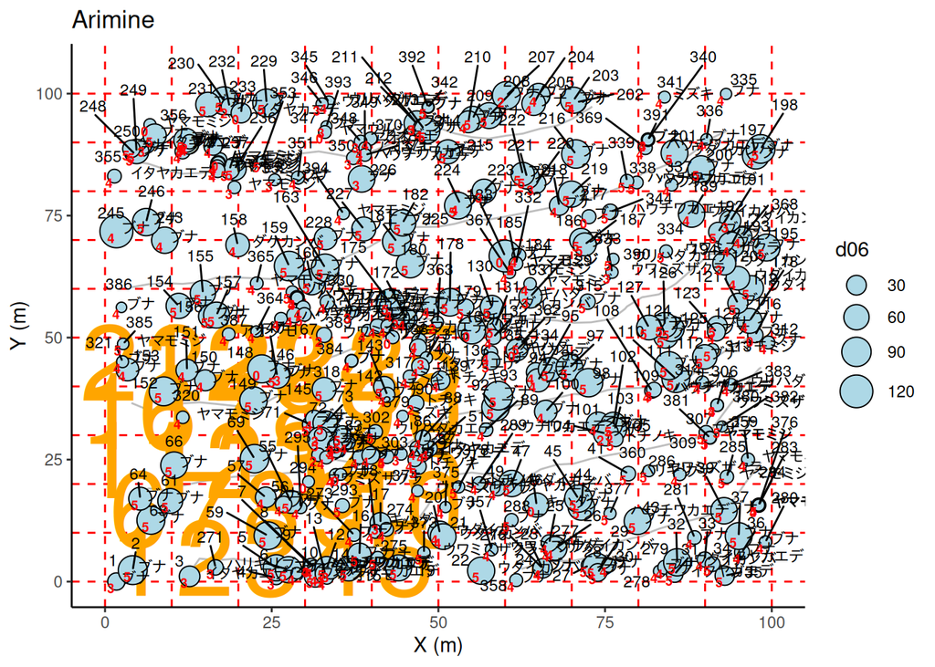

```r
treemap("Arimine")
```

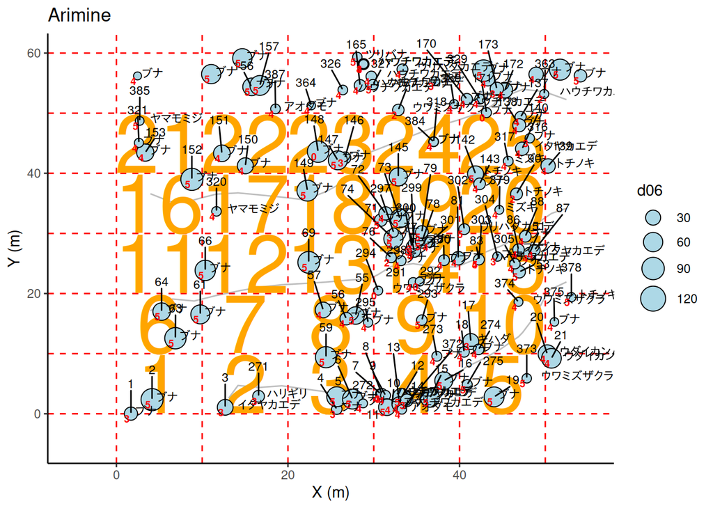

```r
 treemap("Arimine")+ ggplot2::xlim(c(-5, 55))+ ggplot2::ylim(c(-5, 60))
```

# 野帳入力と集計

## 入力

野外調査で植生調査記録ExelやCalcで，スプレッド・シートに植生調査記録したデータを入力します

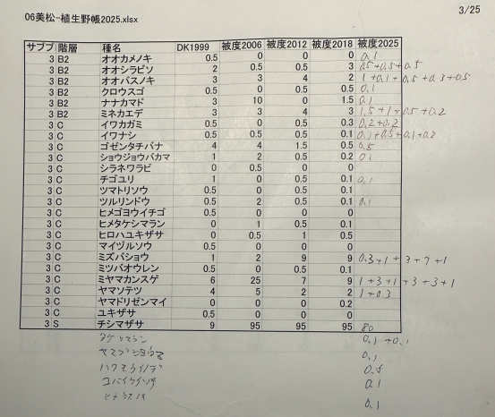

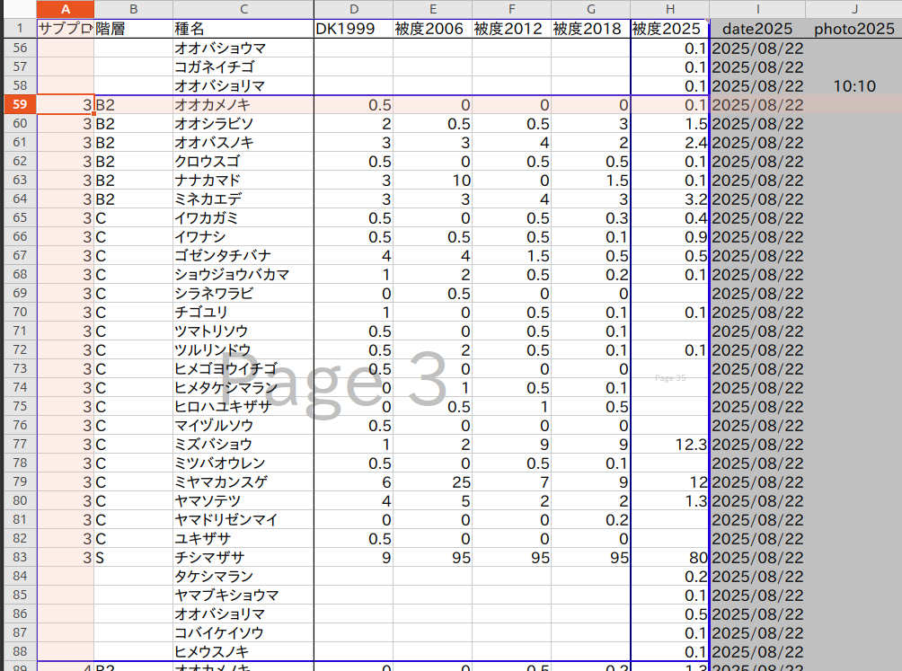

## 野帳データの整理 (R)

### ワーキング・ディレクトリの設定

### 入力値の異常値が無いか確認

### 空白埋め

サブプロットと階層が空白になっているのを埋める

## 集計・作図作業

### 被度とDomin-Krajina変換

被度(一般的な被覆率)とDomin-Krajina被度の関係

```r
Domin_Krajina
```

```
## function(cv) {
##   ifelse(cv == 100, 10,
##          ifelse(cv >= 75, 9,
##                 ifelse(cv >= 50, 8,
##                        ifelse(cv >= 33, 7,
##                               ifelse(cv >= 20, 6,
##                                      ifelse(cv >= 10, 5,
##                                             ifelse(cv >= 5,  4,
##                                                    ifelse(cv >= 3,  3,
##                                                           ifelse(cv >= 2,  2,
##                                                                  ifelse(cv >= 1,  1,
##                                                                         ifelse(cv >  0,  0.5,
##                                                                                0)))))))))))
## }
## <bytecode: 0x5d67e03ae210>
## <environment: namespace:TateyamaVegetation>
```

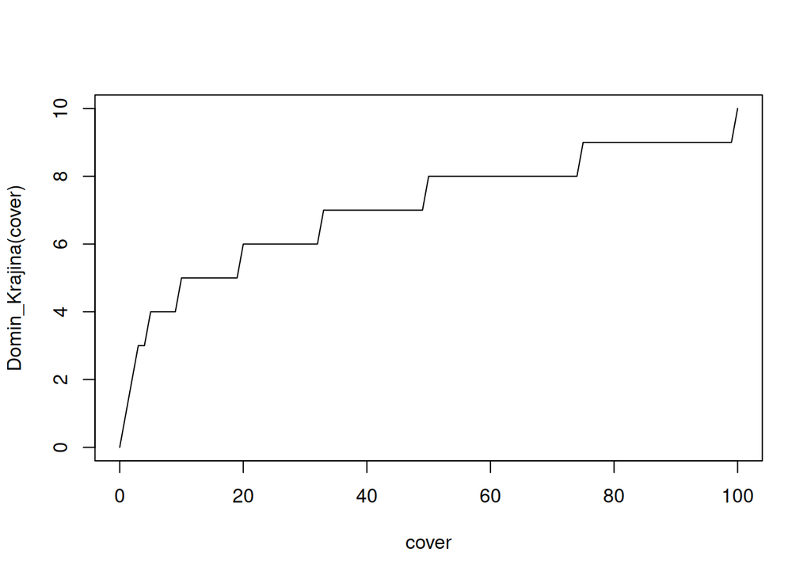

```r
cover<-seq(0,100,1)
plot(cover, Domin_Krajina(cover),type="l")
```

### 総合優占度(Kojima2006)の計算

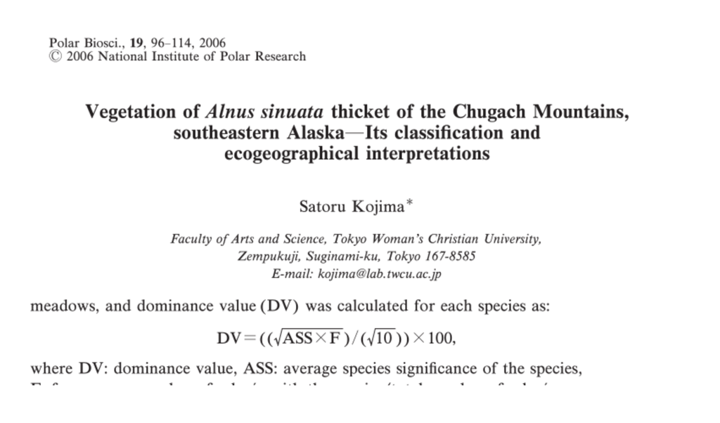

総合優占度 = 100 * sqrt(平均被度 * 出現頻度 / sqrt(10)

## 2025年度の事例

### 美松・有峰

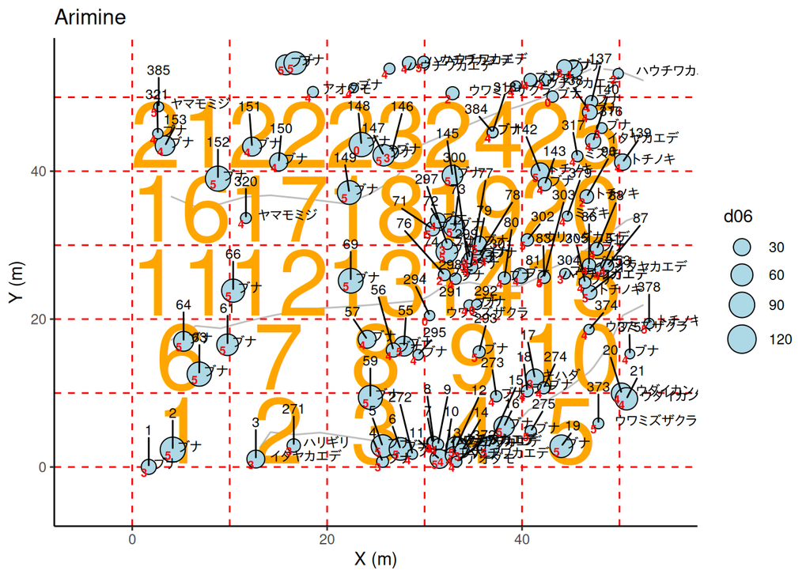

```r
# treemap("Amimine")
# treemap("Mimatsu")+ ggplot2::ylim(c(45, 105))
treemap("Arimine")+ ggplot2::xlim(c(-5, 55))+ ggplot2::ylim(c(-5, 55))
```

# これまでの結果

```r
subset(vv,plot=="Arimine")
```

| pn | plot | subplot | layer | sp | dk01 | c02 | c03 | c04 | c05 |
| --- | --- | --- | --- | --- | --- | --- | --- | --- | --- |
| 10 | Arimine | 1 | B2 | アオダモ | 0.0 | 1.0 | 1.0 | 1.00 | 0 |
| 10 | Arimine | 1 | B2 | イタヤカエデ | 0.5 | 0.5 | 1.0 | 0.30 | 0 |
| 10 | Arimine | 1 | B2 | ウリハダカエデ | 0.0 | 12.0 | 3.0 | 0.50 | 0 |
| 10 | Arimine | 1 | B2 | ウワミズザクラ | 4.0 | 5.0 | 5.0 | 0.80 | 0 |
| 10 | Arimine | 1 | B2 | オオカメノキ | 5.0 | 10.0 | 5.0 | 14.00 | 0 |
| 10 | Arimine | 1 | B2 | オオバクロモジ | 5.0 | 18.0 | 15.0 | 10.00 | 0 |
| 10 | Arimine | 1 | B2 | コシアブラ | 0.0 | 1.0 | 1.0 | 4.00 | 0 |
| 10 | Arimine | 1 | B2 | コマユミ | 2.0 | 0.0 | 0.0 | 0.10 | 0 |
| 10 | Arimine | 1 | B2 | サワフタギ | 2.0 | 4.0 | 3.0 | 2.00 | 0 |
| 10 | Arimine | 1 | B2 | タムシバ | 0.0 | 0.0 | 2.0 | 3.00 | 0 |

[output cut: 873 more lines]

## 植生表

```r
names(VT)
```

```
##  [1] "Bijodaira_dk01"     "Bijodaira_c02"      "Bijodaira_c03"
##  [4] "Bijodaira_c04"      "Bijodaira_c05"      "Bunazaka_dk01"
##  [7] "Bunazaka_c02"       "Bunazaka_c03"       "Bunazaka_c04"
## [10] "Bunazaka_c05"       "Bunadaira_dk01"     "Bunadaira_c02"
## [13] "Bunadaira_c03"      "Bunadaira_c04"      "Bunadaira_c05"
## [16] "Kaminokodaira_dk01" "Kaminokodaira_c02"  "Kaminokodaira_c03"
## [19] "Kaminokodaira_c04"  "Kaminokodaira_c05"  "Midagahara_dk01"
## [22] "Midagahara_c02"     "Midagahara_c03"     "Midagahara_c04"
## [25] "Midagahara_c05"     "Mimatsu_dk01"       "Mimatsu_c02"
## [28] "Mimatsu_c03"        "Mimatsu_c04"        "Mimatsu_c05"
## [31] "Matsuotoge_dk01"    "Matsuotoge_c02"     "Matsuotoge_c03"
## [34] "Matsuotoge_c04"     "Matsuotoge_c05"     "Kagamiishi_dk01"
## [37] "Kagamiishi_c02"     "Kagamiishi_c03"     "Kagamiishi_c04"
## [40] "Kagamiishi_c05"     "Joudosan_dk01"      "Joudosan_c02"
## [43] "Joudosan_c03"       "Joudosan_c04"       "Joudosan_c05"
## [46] "Arimine_dk01"       "Arimine_c02"        "Arimine_c03"
## [49] "Arimine_c04"        "Arimine_c05"
```

```r
VT[["Arimine_c04" ]]
```

| sp | 1 | 2 | 3 | 4 | 5 | 6 | 7 | 8 | 9 | 10 | 11 | 12 | 13 | 14 | 15 | 16 | 17 | 18 | 19 | 20 | 21 | 22 | 23 | 24 | 25 | Mean | Frequency | FreqCode | DominatIndex |
| --- | --- | --- | --- | --- | --- | --- | --- | --- | --- | --- | --- | --- | --- | --- | --- | --- | --- | --- | --- | --- | --- | --- | --- | --- | --- | --- | --- | --- | --- |
| アオダモ | 1.0 | 3.5 | 0.5 | 3.0 | 0.0 | 0.0 | 1.0 | 1.0 | 0.0 | 0.0 | 1.0 | 3.0 | 2.0 | 0.0 | 0.1 | 2.0 | 5.0 | 1.0 | 0.0 | 0.2 | 0.20 | 0.1 | 0.2 | 0.1 | 0.1 | 1.0000 | 0.76923077 | Ⅳ | 27.7350098 |
| イタヤカエデ | 0.3 | 0.0 | 0.0 | 0.0 | 0.5 | 0.5 | 0.5 | 0.0 | 0.0 | 0.0 | 0.5 | 0.5 | 0.5 | 0.0 | 0.2 | 0.1 | 0.5 | 0.0 | 0.0 | 0.0 | 0.20 | 0.1 | 0.1 | 0.0 | 0.3 | 0.1920 | 0.57692308 | Ⅲ | 10.5246962 |
| ウリハダカエデ | 0.5 | 13.0 | 1.5 | 2.0 | 10.0 | 1.0 | 6.0 | 4.0 | 1.0 | 2.0 | 1.0 | 2.0 | 1.0 | 5.0 | 2.0 | 0.2 | 3.4 | 6.0 | 4.0 | 0.6 | 0.50 | 5.0 | 1.0 | 0.5 | 0.2 | 2.9360 | 1.00000000 | Ⅴ | 54.1848687 |
| ウワミズザクラ | 0.8 | 3.0 | 3.0 | 3.0 | 4.0 | 2.0 | 4.0 | 0.5 | 2.0 | 5.0 | 0.0 | 1.0 | 2.0 | 2.0 | 3.0 | 0.0 | 1.5 | 5.0 | 2.0 | 1.0 | 6.00 | 0.1 | 4.0 | 5.0 | 1.0 | 2.4360 | 0.92307692 | Ⅴ | 47.4195675 |
| オオカメノキ | 14.0 | 37.0 | 30.0 | 20.0 | 15.0 | 25.0 | 23.0 | 35.0 | 21.0 | 4.0 | 20.0 | 20.0 | 20.0 | 10.0 | 4.0 | 13.0 | 17.0 | 14.0 | 11.0 | 10.0 | 18.00 | 15.0 | 5.0 | 6.0 | 7.0 | 16.5600 | 1.00000000 | Ⅴ | 128.6856635 |
| オオバクロモジ | 10.0 | 25.0 | 20.0 | 4.0 | 6.0 | 18.0 | 15.0 | 19.0 | 7.0 | 7.0 | 13.0 | 8.0 | 25.0 | 3.0 | 3.0 | 4.0 | 6.0 | 13.0 | 12.0 | 2.0 | 2.00 | 6.0 | 6.0 | 3.0 | 1.0 | 9.5200 | 1.00000000 | Ⅴ | 97.5704873 |
| コシアブラ | 4.0 | 0.0 | 5.5 | 1.5 | 0.7 | 0.0 | 1.0 | 4.0 | 0.0 | 2.0 | 3.0 | 4.0 | 14.0 | 1.0 | 0.5 | 0.1 | 1.0 | 3.0 | 4.0 | 0.5 | 0.20 | 0.1 | 5.0 | 0.5 | 0.3 | 2.2360 | 0.88461538 | Ⅴ | 44.4747119 |
| コマユミ | 0.1 | 0.5 | 0.0 | 0.5 | 0.5 | 0.5 | 0.5 | 0.0 | 0.5 | 0.0 | 0.2 | 0.2 | 0.2 | 0.5 | 0.2 | 0.2 | 0.0 | 0.0 | 0.0 | 0.1 | 0.50 | 0.0 | 0.0 | 0.0 | 0.0 | 0.2080 | 0.61538462 | Ⅳ | 11.3137085 |
| サワフタギ | 2.0 | 0.0 | 0.0 | 0.0 | 0.0 | 0.0 | 0.0 | 1.5 | 7.0 | 0.5 | 0.0 | 0.0 | 1.0 | 0.0 | 0.0 | 0.0 | 0.0 | 0.0 | 7.0 | 4.0 | 0.00 | 0.0 | 5.0 | 2.0 | 10.0 | 1.6000 | 0.42307692 | Ⅲ | 26.0177454 |
| タムシバ | 3.0 | 0.0 | 0.0 | 0.0 | 0.0 | 0.0 | 0.0 | 0.5 | 0.5 | 0.0 | 0.0 | 0.0 | 0.0 | 0.5 | 0.0 | 0.0 | 0.0 | 0.0 | 0.0 | 0.2 | 0.00 | 0.0 | 0.0 | 0.0 | 0.0 | 0.1880 | 0.23076923 | Ⅱ | 6.5866999 |

[output cut: 73 more lines]

## 植生表

```r
names(VT)
```

```
##  [1] "Bijodaira_dk01"     "Bijodaira_c02"      "Bijodaira_c03"
##  [4] "Bijodaira_c04"      "Bijodaira_c05"      "Bunazaka_dk01"
##  [7] "Bunazaka_c02"       "Bunazaka_c03"       "Bunazaka_c04"
## [10] "Bunazaka_c05"       "Bunadaira_dk01"     "Bunadaira_c02"
## [13] "Bunadaira_c03"      "Bunadaira_c04"      "Bunadaira_c05"
## [16] "Kaminokodaira_dk01" "Kaminokodaira_c02"  "Kaminokodaira_c03"
## [19] "Kaminokodaira_c04"  "Kaminokodaira_c05"  "Midagahara_dk01"
## [22] "Midagahara_c02"     "Midagahara_c03"     "Midagahara_c04"
## [25] "Midagahara_c05"     "Mimatsu_dk01"       "Mimatsu_c02"
## [28] "Mimatsu_c03"        "Mimatsu_c04"        "Mimatsu_c05"
## [31] "Matsuotoge_dk01"    "Matsuotoge_c02"     "Matsuotoge_c03"
## [34] "Matsuotoge_c04"     "Matsuotoge_c05"     "Kagamiishi_dk01"
## [37] "Kagamiishi_c02"     "Kagamiishi_c03"     "Kagamiishi_c04"
## [40] "Kagamiishi_c05"     "Joudosan_dk01"      "Joudosan_c02"
## [43] "Joudosan_c03"       "Joudosan_c04"       "Joudosan_c05"
## [46] "Arimine_dk01"       "Arimine_c02"        "Arimine_c03"
## [49] "Arimine_c04"        "Arimine_c05"
```

```r
VT[["Arimine_c04" ]]
```

| sp | 1 | 2 | 3 | 4 | 5 | 6 | 7 | 8 | 9 | 10 | 11 | 12 | 13 | 14 | 15 | 16 | 17 | 18 | 19 | 20 | 21 | 22 | 23 | 24 | 25 | Mean | Frequency | FreqCode | DominatIndex |
| --- | --- | --- | --- | --- | --- | --- | --- | --- | --- | --- | --- | --- | --- | --- | --- | --- | --- | --- | --- | --- | --- | --- | --- | --- | --- | --- | --- | --- | --- |
| アオダモ | 1.0 | 3.5 | 0.5 | 3.0 | 0.0 | 0.0 | 1.0 | 1.0 | 0.0 | 0.0 | 1.0 | 3.0 | 2.0 | 0.0 | 0.1 | 2.0 | 5.0 | 1.0 | 0.0 | 0.2 | 0.20 | 0.1 | 0.2 | 0.1 | 0.1 | 1.0000 | 0.76923077 | Ⅳ | 27.7350098 |
| イタヤカエデ | 0.3 | 0.0 | 0.0 | 0.0 | 0.5 | 0.5 | 0.5 | 0.0 | 0.0 | 0.0 | 0.5 | 0.5 | 0.5 | 0.0 | 0.2 | 0.1 | 0.5 | 0.0 | 0.0 | 0.0 | 0.20 | 0.1 | 0.1 | 0.0 | 0.3 | 0.1920 | 0.57692308 | Ⅲ | 10.5246962 |
| ウリハダカエデ | 0.5 | 13.0 | 1.5 | 2.0 | 10.0 | 1.0 | 6.0 | 4.0 | 1.0 | 2.0 | 1.0 | 2.0 | 1.0 | 5.0 | 2.0 | 0.2 | 3.4 | 6.0 | 4.0 | 0.6 | 0.50 | 5.0 | 1.0 | 0.5 | 0.2 | 2.9360 | 1.00000000 | Ⅴ | 54.1848687 |
| ウワミズザクラ | 0.8 | 3.0 | 3.0 | 3.0 | 4.0 | 2.0 | 4.0 | 0.5 | 2.0 | 5.0 | 0.0 | 1.0 | 2.0 | 2.0 | 3.0 | 0.0 | 1.5 | 5.0 | 2.0 | 1.0 | 6.00 | 0.1 | 4.0 | 5.0 | 1.0 | 2.4360 | 0.92307692 | Ⅴ | 47.4195675 |
| オオカメノキ | 14.0 | 37.0 | 30.0 | 20.0 | 15.0 | 25.0 | 23.0 | 35.0 | 21.0 | 4.0 | 20.0 | 20.0 | 20.0 | 10.0 | 4.0 | 13.0 | 17.0 | 14.0 | 11.0 | 10.0 | 18.00 | 15.0 | 5.0 | 6.0 | 7.0 | 16.5600 | 1.00000000 | Ⅴ | 128.6856635 |
| オオバクロモジ | 10.0 | 25.0 | 20.0 | 4.0 | 6.0 | 18.0 | 15.0 | 19.0 | 7.0 | 7.0 | 13.0 | 8.0 | 25.0 | 3.0 | 3.0 | 4.0 | 6.0 | 13.0 | 12.0 | 2.0 | 2.00 | 6.0 | 6.0 | 3.0 | 1.0 | 9.5200 | 1.00000000 | Ⅴ | 97.5704873 |
| コシアブラ | 4.0 | 0.0 | 5.5 | 1.5 | 0.7 | 0.0 | 1.0 | 4.0 | 0.0 | 2.0 | 3.0 | 4.0 | 14.0 | 1.0 | 0.5 | 0.1 | 1.0 | 3.0 | 4.0 | 0.5 | 0.20 | 0.1 | 5.0 | 0.5 | 0.3 | 2.2360 | 0.88461538 | Ⅴ | 44.4747119 |
| コマユミ | 0.1 | 0.5 | 0.0 | 0.5 | 0.5 | 0.5 | 0.5 | 0.0 | 0.5 | 0.0 | 0.2 | 0.2 | 0.2 | 0.5 | 0.2 | 0.2 | 0.0 | 0.0 | 0.0 | 0.1 | 0.50 | 0.0 | 0.0 | 0.0 | 0.0 | 0.2080 | 0.61538462 | Ⅳ | 11.3137085 |
| サワフタギ | 2.0 | 0.0 | 0.0 | 0.0 | 0.0 | 0.0 | 0.0 | 1.5 | 7.0 | 0.5 | 0.0 | 0.0 | 1.0 | 0.0 | 0.0 | 0.0 | 0.0 | 0.0 | 7.0 | 4.0 | 0.00 | 0.0 | 5.0 | 2.0 | 10.0 | 1.6000 | 0.42307692 | Ⅲ | 26.0177454 |
| タムシバ | 3.0 | 0.0 | 0.0 | 0.0 | 0.0 | 0.0 | 0.0 | 0.5 | 0.5 | 0.0 | 0.0 | 0.0 | 0.0 | 0.5 | 0.0 | 0.0 | 0.0 | 0.0 | 0.0 | 0.2 | 0.00 | 0.0 | 0.0 | 0.0 | 0.0 | 0.1880 | 0.23076923 | Ⅱ | 6.5866999 |

[output cut: 73 more lines]

# I-V集計表

## 1. 美女平

```r
plot_name　<-　"Bijodaira"
DT_VCrepo(plot_name)
```

|  | layer | sp | form | f1 | f2 | f3 | f4 | f5 | F1 | F2 | F3 | F4 | F5 | c1 | c2 | c3 | c4 | c5 | di1 | di2 | di3 | di4 | di5 | cal |
| --- | --- | --- | --- | --- | --- | --- | --- | --- | --- | --- | --- | --- | --- | --- | --- | --- | --- | --- | --- | --- | --- | --- | --- | --- |
| 1 | B2 | アオダモ | bl | 0.3461538461538461 | 0.5 | 0.8076923076923077 | 0.8461538461538461 | 0.8846153846153846 | Ⅱ | Ⅲ | Ⅴ | Ⅴ | Ⅴ | 0.16 | 0.26 | 0.56 | 0.66 | 0.716 | 7.442084075352507 | 11.40175425099138 | 21.267526708757 | 23.98717606106678 | 25.9288968586728 | 1 |
| 2 | B2 | アカミノイヌツゲ | bs | 0.1538461538461539 | 0.1153846153846154 | 0.07692307692307693 | 0.07692307692307693 | 0.1153846153846154 | Ⅰ | Ⅰ | Ⅰ | Ⅰ | Ⅰ | 0.06 | 0.04 | 0.08 | 0.04 | 0.06 | 3.038218101251 | 2.148344622118298 | 2.480694691784169 | 1.754116038614059 | 2.631174057921087 | 1 |
| 3 | B2 | アクシバ | bs | 0.1538461538461539 | 0.07692307692307693 | 0.2307692307692308 | 0.1923076923076923 | 0.3461538461538461 | Ⅰ | Ⅰ | Ⅱ | Ⅰ | Ⅱ | 0.08 | 0.02 | 0.22 | 0.112 | 0.176 | 3.508232077228117 | 1.240347345892085 | 7.125253031944252 | 5.188745216627709 | 8.726617108241093 | 1 |
| 4 | B2 | イタヤカエデ | bl | 0 | 0 | 0.07692307692307693 | 0.07692307692307693 | 0.1153846153846154 | - | - | Ⅰ | Ⅰ | Ⅰ | 0 | 0 | 0.02 | 0.02 | 0.024 | 0 | 0 | 1.240347345892085 | 1.240347345892085 | 2.148344622118298 | 0 |
| 5 | B2 | ウリハダカエデ | bl | 0.5384615384615384 | 0.5769230769230769 | 0.8846153846153846 | 0.9230769230769231 | 1 | Ⅲ | Ⅲ | Ⅴ | Ⅴ | Ⅴ | 0.76 | 1.14 | 1.46 | 1.068 | 1.192 | 20.2294530136326 | 21.21320343559642 | 33.91164991562634 | 31.28036985813209 | 33.16624790355399 | 1 |
| 6 | B2 | ウワミズザクラ | bl | 0.4615384615384616 | 0.4230769230769231 | 0.5769230769230769 | 0.7307692307692307 | 0.5 | Ⅲ | Ⅲ | Ⅲ | Ⅳ | Ⅲ | 0.68 | 0.78 | 0.62 | 0.636 | 0.432 | 17.71570359444281 | 18.16590212458495 | 18.29249530860633 | 22.61721604306024 | 14.49137674618944 | 1 |
| 7 | B2 | エゾアジサイ | bs | 0.1153846153846154 | 0 | 0 | 0 | 0 | Ⅰ | - | - | - | - | 0.28 | 0 | 0 | 0 | 0 | 5.683985600588051 | 0 | 0 | 0 | 0 | 0 |
| 8 | B2 | エゾユズリハ | bs | 0.1538461538461539 | 0.1153846153846154 | 0.1923076923076923 | 0.1153846153846154 | 0.2307692307692308 | Ⅰ | Ⅰ | Ⅰ | Ⅰ | Ⅱ | 0.16 | 0.16 | 0.1 | 0.036 | 0.068 | 4.961389383568338 | 4.296689244236597 | 4.385290096535146 | 2.148344622118298 | 4.803844614152615 | 1 |
| 9 | B2 | オオカメノキ | bs | 1 | 1 | 1 | 1 | 1 | Ⅴ | Ⅴ | Ⅴ | Ⅴ | Ⅴ | 3.64 | 6 | 8.84 | 10.68 | 12.04 | 60.33241251599342 | 59.66573556070519 | 65.72670690061994 | 66.93280212272605 | 67.52777206453652 | 1 |
| 10 | B2 | オオバクロモジ | bs | 0.9615384615384616 | 0.9615384615384616 | 1 | 0.9615384615384616 | 1 | Ⅴ | Ⅴ | Ⅴ | Ⅴ | Ⅴ | 3.08 | 4.68 | 6.8 | 4.948 | 4.244 | 54.4200189409969 | 54.06548735632486 | 62.92853089020909 | 54.06548735632486 | 55.13619500836088 | 1 |

[output cut: 127 more lines]

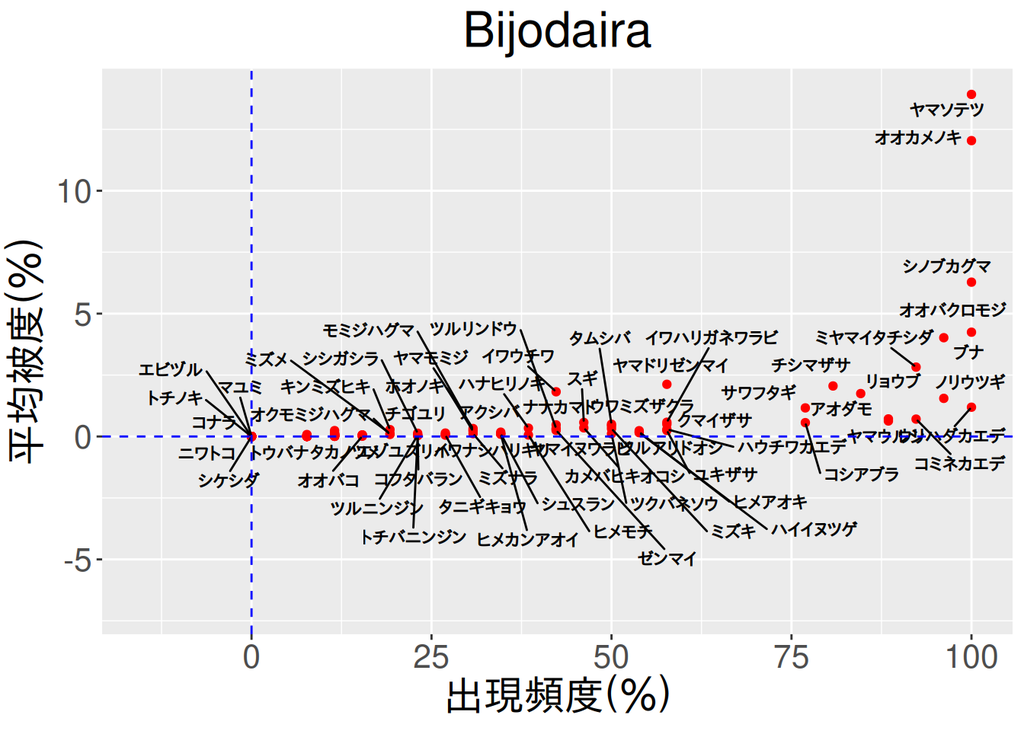

```r
Fig_FrequencyCoverage(plot_name=plot_name,x="f5",y="c5")
```

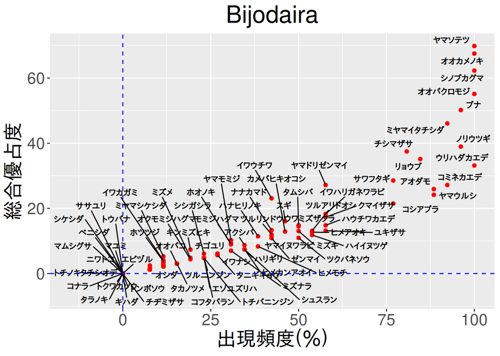

```r
Fig_FrequencyDominace(plot_name=plot_name,x="f5",y="di5")
```

## 2. ブナ坂

```r
plot_name　<-　"Bunazaka"
DT_VCrepo(plot_name)
```

|  | layer | sp | form | f1 | f2 | f3 | f4 | f5 | F1 | F2 | F3 | F4 | F5 | c1 | c2 | c3 | c4 | c5 | di1 | di2 | di3 | di4 | di5 | cal |
| --- | --- | --- | --- | --- | --- | --- | --- | --- | --- | --- | --- | --- | --- | --- | --- | --- | --- | --- | --- | --- | --- | --- | --- | --- |
| 1 | B2 | アオダモ | bl | 0.5862068965517241 | 0.6206896551724138 | 0.7586206896551724 | 0.7241379310344828 | 0.7931034482758621 | Ⅲ | Ⅳ | Ⅳ | Ⅳ | Ⅳ | 0.3214285714285715 | 0.5 | 0.8571428571428571 | 1.164285714285714 | 1.632142857142857 | 13.72674926266948 | 17.6166065854411 | 24.96302684691113 | 27.85430072655778 | 31.48617649612013 | 1 |
| 2 | B2 | アカミノイヌツゲ | bs | 0 | 0 | 0.1379310344827586 | 0.06896551724137931 | 0.1379310344827586 | - | - | Ⅰ | Ⅰ | Ⅰ | 0 | 0 | 0.05357142857142857 | 0.03571428571428571 | 0.04642857142857143 | 0 | 0 | 2.718301411097812 | 1.569412051435861 | 3.138824102871722 | 0 |
| 3 | B2 | アクシバ | bs | 0.3448275862068966 | 0.4482758620689655 | 0.5172413793103449 | 0.5517241379310345 | 0.5172413793103449 | Ⅱ | Ⅲ | Ⅲ | Ⅲ | Ⅲ | 0.1607142857142857 | 0.2321428571428572 | 0.3214285714285715 | 0.2392857142857143 | 0.5035714285714286 | 7.444375004781977 | 10.2011783343331 | 12.89403573887819 | 13.31690284855426 | 16.08168802256692 | 1 |
| 4 | B2 | ウスノキ | bs | 0 | 0 | 0.06896551724137931 | 0.06896551724137931 | 0.06896551724137931 | - | - | Ⅰ | Ⅰ | Ⅰ | 0 | 0 | 0.03571428571428571 | 0.01785714285714286 | 0.05357142857142857 | 0 | 0 | 1.569412051435861 | 1.109741904046188 | 1.569412051435861 | 0 |
| 5 | B2 | ウリハダカエデ | bl | 0.6896551724137931 | 0.6896551724137931 | 0.7586206896551724 | 0.8275862068965517 | 0.8620689655172413 | Ⅳ | Ⅳ | Ⅳ | Ⅴ | Ⅴ | 0.3392857142857143 | 0.3392857142857143 | 0.4642857142857143 | 0.45 | 0.4257142857142857 | 15.29673650761009 | 15.29673650761009 | 18.76743852443569 | 20.34190510862431 | 21.84529122645136 | 1 |
| 6 | B2 | ウワミズザクラ | bl | 0.3103448275862069 | 0.4482758620689655 | 0.8620689655172413 | 0.8620689655172413 | 0.896551724137931 | Ⅱ | Ⅲ | Ⅴ | Ⅴ | Ⅴ | 0.1607142857142857 | 0.25 | 0.6607142857142857 | 0.6928571428571428 | 1.025 | 7.062354231461376 | 10.58626305724741 | 23.86590205268129 | 25.12285086267043 | 28.85328950520089 | 1 |
| 7 | B2 | エゾユズリハ | bs | 1 | 1 | 1 | 1 | 0.896551724137931 | Ⅴ | Ⅴ | Ⅴ | Ⅴ | Ⅴ | 4.035714285714286 | 6.607142857142857 | 3.053571428571428 | 2.007142857142857 | 1.867857142857143 | 63.52727198388331 | 62.10590034081188 | 48.73397172404481 | 42.25771273642583 | 37.74754094362493 | 1 |
| 8 | B2 | オオカメノキ | bs | 1 | 0.9655172413793104 | 1 | 1 | 1 | Ⅴ | Ⅴ | Ⅴ | Ⅴ | Ⅴ | 3.946428571428572 | 6.625 | 11.46428571428571 | 10.96428571428571 | 11.17857142857143 | 62.82060626441432 | 61.16681543406381 | 66.54751256486924 | 67.08203932499369 | 67.08203932499369 | 1 |
| 9 | B2 | オオバクロモジ | bs | 0.9310344827586207 | 0.896551724137931 | 1 | 1 | 1 | Ⅴ | Ⅴ | Ⅴ | Ⅴ | Ⅴ | 3.714285714285714 | 6.464285714285714 | 7.071428571428571 | 6.642857142857143 | 8.071428571428571 | 58.80585071927566 | 57.14901444659171 | 63.24555320336759 | 62.10590034081188 | 62.67831705280086 | 1 |
| 10 | B2 | クマイチゴ | bs | 0 | 0.06896551724137931 | 0 | 0 | 0 | - | Ⅰ | - | - | - | 0 | 0.01785714285714286 | 0 | 0 | 0 | 0 | 1.109741904046188 | 0 | 0 | 0 | 0 |

[output cut: 79 more lines]

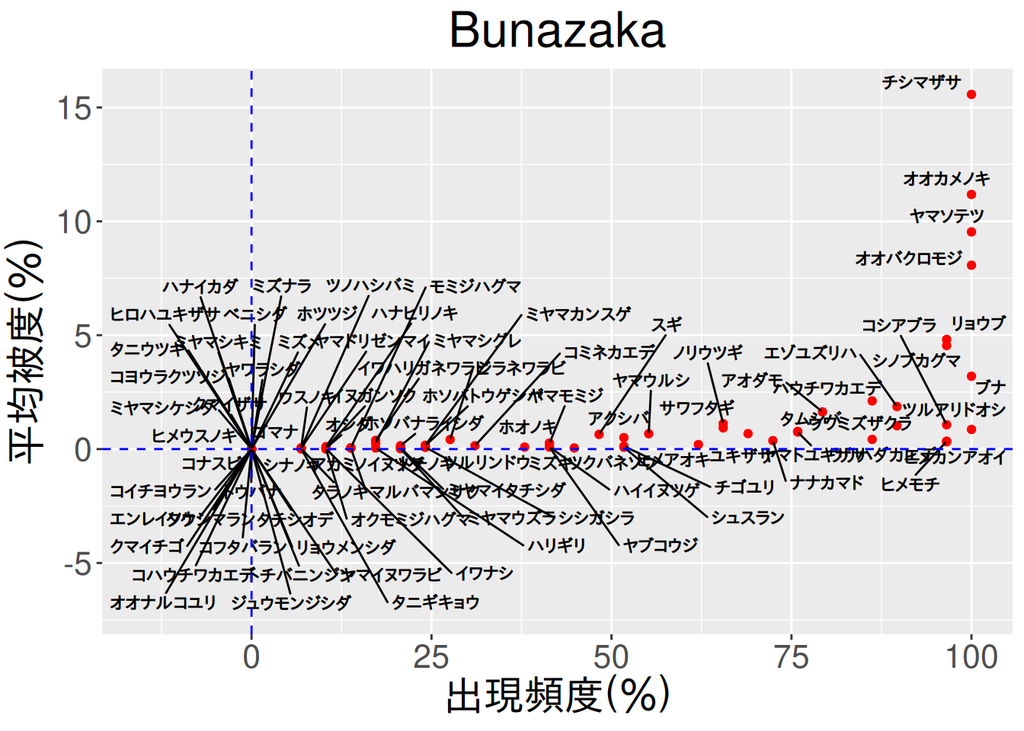

```r
Fig_FrequencyCoverage(plot_name=plot_name,x="f5",y="c5")
```

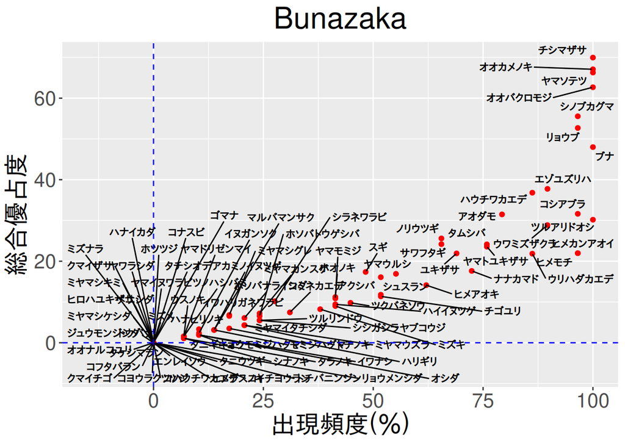

```r
Fig_FrequencyDominace(plot_name=plot_name,x="f5",y="di5")
```

```r
plot_name　<-　"Bunazaka"
DT_VCrepo(plot_name)
```

|  | layer | sp | form | f1 | f2 | f3 | f4 | f5 | F1 | F2 | F3 | F4 | F5 | c1 | c2 | c3 | c4 | c5 | di1 | di2 | di3 | di4 | di5 | cal |
| --- | --- | --- | --- | --- | --- | --- | --- | --- | --- | --- | --- | --- | --- | --- | --- | --- | --- | --- | --- | --- | --- | --- | --- | --- |
| 1 | B2 | アオダモ | bl | 0.5862068965517241 | 0.6206896551724138 | 0.7586206896551724 | 0.7241379310344828 | 0.7931034482758621 | Ⅲ | Ⅳ | Ⅳ | Ⅳ | Ⅳ | 0.3214285714285715 | 0.5 | 0.8571428571428571 | 1.164285714285714 | 1.632142857142857 | 13.72674926266948 | 17.6166065854411 | 24.96302684691113 | 27.85430072655778 | 31.48617649612013 | 1 |
| 2 | B2 | アカミノイヌツゲ | bs | 0 | 0 | 0.1379310344827586 | 0.06896551724137931 | 0.1379310344827586 | - | - | Ⅰ | Ⅰ | Ⅰ | 0 | 0 | 0.05357142857142857 | 0.03571428571428571 | 0.04642857142857143 | 0 | 0 | 2.718301411097812 | 1.569412051435861 | 3.138824102871722 | 0 |
| 3 | B2 | アクシバ | bs | 0.3448275862068966 | 0.4482758620689655 | 0.5172413793103449 | 0.5517241379310345 | 0.5172413793103449 | Ⅱ | Ⅲ | Ⅲ | Ⅲ | Ⅲ | 0.1607142857142857 | 0.2321428571428572 | 0.3214285714285715 | 0.2392857142857143 | 0.5035714285714286 | 7.444375004781977 | 10.2011783343331 | 12.89403573887819 | 13.31690284855426 | 16.08168802256692 | 1 |
| 4 | B2 | ウスノキ | bs | 0 | 0 | 0.06896551724137931 | 0.06896551724137931 | 0.06896551724137931 | - | - | Ⅰ | Ⅰ | Ⅰ | 0 | 0 | 0.03571428571428571 | 0.01785714285714286 | 0.05357142857142857 | 0 | 0 | 1.569412051435861 | 1.109741904046188 | 1.569412051435861 | 0 |
| 5 | B2 | ウリハダカエデ | bl | 0.6896551724137931 | 0.6896551724137931 | 0.7586206896551724 | 0.8275862068965517 | 0.8620689655172413 | Ⅳ | Ⅳ | Ⅳ | Ⅴ | Ⅴ | 0.3392857142857143 | 0.3392857142857143 | 0.4642857142857143 | 0.45 | 0.4257142857142857 | 15.29673650761009 | 15.29673650761009 | 18.76743852443569 | 20.34190510862431 | 21.84529122645136 | 1 |
| 6 | B2 | ウワミズザクラ | bl | 0.3103448275862069 | 0.4482758620689655 | 0.8620689655172413 | 0.8620689655172413 | 0.896551724137931 | Ⅱ | Ⅲ | Ⅴ | Ⅴ | Ⅴ | 0.1607142857142857 | 0.25 | 0.6607142857142857 | 0.6928571428571428 | 1.025 | 7.062354231461376 | 10.58626305724741 | 23.86590205268129 | 25.12285086267043 | 28.85328950520089 | 1 |
| 7 | B2 | エゾユズリハ | bs | 1 | 1 | 1 | 1 | 0.896551724137931 | Ⅴ | Ⅴ | Ⅴ | Ⅴ | Ⅴ | 4.035714285714286 | 6.607142857142857 | 3.053571428571428 | 2.007142857142857 | 1.867857142857143 | 63.52727198388331 | 62.10590034081188 | 48.73397172404481 | 42.25771273642583 | 37.74754094362493 | 1 |
| 8 | B2 | オオカメノキ | bs | 1 | 0.9655172413793104 | 1 | 1 | 1 | Ⅴ | Ⅴ | Ⅴ | Ⅴ | Ⅴ | 3.946428571428572 | 6.625 | 11.46428571428571 | 10.96428571428571 | 11.17857142857143 | 62.82060626441432 | 61.16681543406381 | 66.54751256486924 | 67.08203932499369 | 67.08203932499369 | 1 |
| 9 | B2 | オオバクロモジ | bs | 0.9310344827586207 | 0.896551724137931 | 1 | 1 | 1 | Ⅴ | Ⅴ | Ⅴ | Ⅴ | Ⅴ | 3.714285714285714 | 6.464285714285714 | 7.071428571428571 | 6.642857142857143 | 8.071428571428571 | 58.80585071927566 | 57.14901444659171 | 63.24555320336759 | 62.10590034081188 | 62.67831705280086 | 1 |
| 10 | B2 | クマイチゴ | bs | 0 | 0.06896551724137931 | 0 | 0 | 0 | - | Ⅰ | - | - | - | 0 | 0.01785714285714286 | 0 | 0 | 0 | 0 | 1.109741904046188 | 0 | 0 | 0 | 0 |

[output cut: 79 more lines]

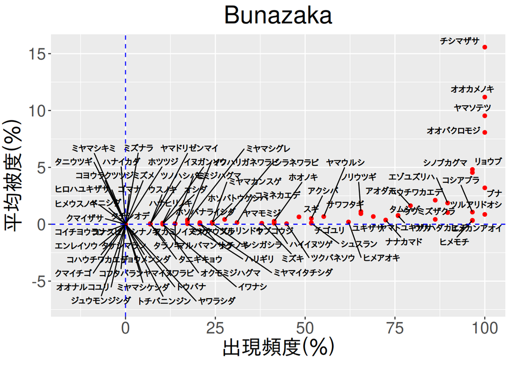

```r
Fig_FrequencyCoverage(plot_name=plot_name,x="f5",y="c5")
```

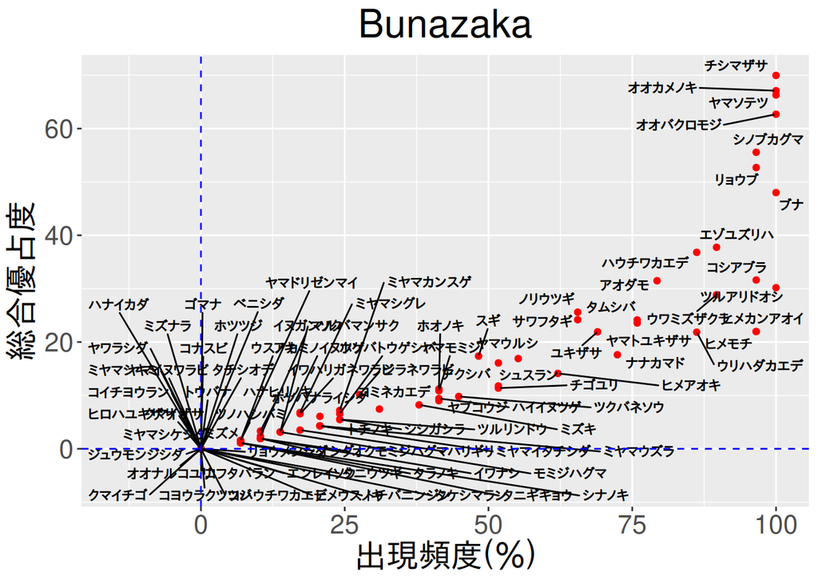

```r
Fig_FrequencyDominace(plot_name=plot_name,x="f5",y="di5")
```

## 4. 上ノ小平

```r
plot_name　<-　"Kaminokodaira"
DT_VCrepo(plot_name)
```

|  | layer | sp | form | f1 | f2 | f3 | f4 | f5 | F1 | F2 | F3 | F4 | F5 | c1 | c2 | c3 | c4 | c5 | di1 | di2 | di3 | di4 | di5 | cal |
| --- | --- | --- | --- | --- | --- | --- | --- | --- | --- | --- | --- | --- | --- | --- | --- | --- | --- | --- | --- | --- | --- | --- | --- | --- |
| 1 | B2 | アオダモ | bl | 0.07692307692307693 | 0.07692307692307693 | 0.2307692307692308 | 0.2307692307692308 | 0.2307692307692308 | Ⅰ | Ⅰ | Ⅱ | Ⅱ | Ⅱ | 0.04 | 0.08 | 0.068 | 0.044 | 0.132 | 1.754116038614059 | 2.480694691784169 | 4.803844614152615 | 4.803844614152615 | 5.683985600588051 | 1 |
| 2 | B2 | アカミノイヌツゲ | bs | 0.7307692307692307 | 0.4230769230769231 | 0.7692307692307693 | 0.8461538461538461 | 0.7692307692307693 | Ⅳ | Ⅲ | Ⅳ | Ⅴ | Ⅳ | 0.86 | 0.58 | 0.496 | 0.722 | 0.488 | 25.06913517578016 | 15.11494420967336 | 21.83856856396675 | 25.02306628200961 | 21.12235418114766 | 1 |
| 3 | B2 | アクシバ | bs | 0.3461538461538461 | 0.3846153846153846 | 0.8076923076923077 | 0.8846153846153846 | 0.9230769230769231 | Ⅱ | Ⅱ | Ⅴ | Ⅴ | Ⅴ | 0.22 | 0.26 | 0.356 | 0.308 | 0.372 | 8.726617108241093 | 10 | 20.09592381171251 | 20.17233444406167 | 21.90890230020664 | 1 |
| 4 | B2 | ウスノキ | bs | 0 | 0.1153846153846154 | 0 | 0 | 0 | - | Ⅰ | - | - | - | 0 | 0.04 | 0 | 0 | 0 | 0 | 2.148344622118298 | 0 | 0 | 0 | 0 |
| 5 | B2 | ウラジロヨウラク | bs | 0 | 0.1153846153846154 | 0.1923076923076923 | 0.1923076923076923 | 0.1153846153846154 | - | Ⅰ | Ⅰ | Ⅰ | Ⅰ | 0 | 0.14 | 0.148 | 0.12 | 0.044 | 0 | 4.019184762342501 | 5.88348405414552 | 4.803844614152615 | 2.631174057921087 | 0 |
| 6 | B2 | ウリハダカエデ | bl | 0 | 0 | 0.1153846153846154 | 0 | 0.07692307692307693 | - | - | Ⅰ | - | Ⅰ | 0 | 0 | 0.008 | 0 | 0.004 | 0 | 0 | 2.148344622118298 | 0 | 1.240347345892085 | 0 |
| 7 | B2 | ウワミズザクラ | bl | 0.07692307692307693 | 0.1153846153846154 | 0.07692307692307693 | 0.1153846153846154 | 0.1153846153846154 | Ⅰ | Ⅰ | Ⅰ | Ⅰ | Ⅰ | 0.02 | 0.22 | 0.04 | 0.22 | 0.016 | 1.240347345892085 | 4.557327151876499 | 1.754116038614059 | 4.803844614152615 | 2.148344622118298 | 1 |
| 8 | B2 | エゾユズリハ | bs | 0 | 0 | 0.07692307692307693 | 0 | 0 | - | - | Ⅰ | - | - | 0 | 0 | 0.02 | 0 | 0 | 0 | 0 | 1.240347345892085 | 0 | 0 | 0 |
| 9 | B2 | オオカメノキ | bs | 0.8461538461538461 | 0.8076923076923077 | 0.8846153846153846 | 1 | 1 | Ⅴ | Ⅴ | Ⅴ | Ⅴ | Ⅴ | 3.88 | 8.56 | 4.164 | 5.232 | 4.96 | 57.29814065985843 | 54.51887464271152 | 48.69054559942033 | 58.309518948453 | 59.66573556070519 | 1 |
| 10 | B2 | オオシラビソ | cl | 0.8461538461538461 | 0.7307692307692307 | 0.9230769230769231 | 0.9230769230769231 | 0.8846153846153846 | Ⅴ | Ⅳ | Ⅴ | Ⅴ | Ⅴ | 2.38 | 2.32 | 1.028 | 0.9 | 0.84 | 44.87589724836879 | 37.0654307117313 | 31.28036985813209 | 27.84572885353543 | 26.93296521708323 | 1 |

[output cut: 101 more lines]

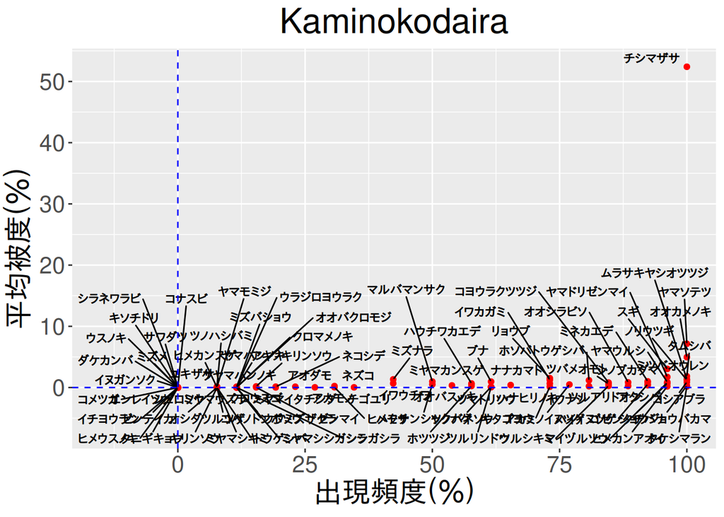

```r
Fig_FrequencyCoverage(plot_name=plot_name,x="f5",y="c5")
```

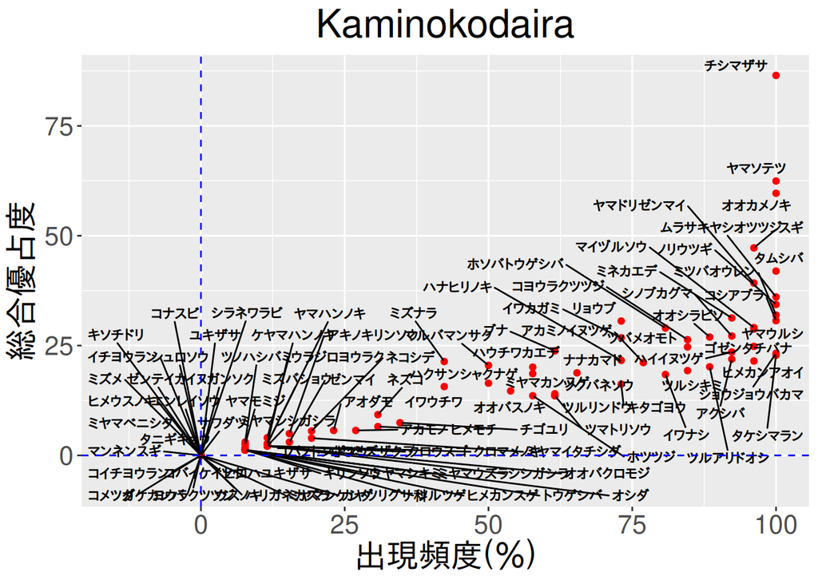

```r
Fig_FrequencyDominace(plot_name=plot_name,x="f5",y="di5")
```

## 5. 弥陀ヶ原

```r
plot_name　<-"Midagahara"
DT_VCrepo(plot_name)
```

|  | layer | sp | form | f1 | f2 | f3 | f4 | f5 | F1 | F2 | F3 | F4 | F5 | c1 | c2 | c3 | c4 | c5 | di1 | di2 | di3 | di4 | di5 | cal |
| --- | --- | --- | --- | --- | --- | --- | --- | --- | --- | --- | --- | --- | --- | --- | --- | --- | --- | --- | --- | --- | --- | --- | --- | --- |
| 1 | B2 | オオシラビソ | cl | 0.09523809523809523 | 0.09523809523809523 | 0.09523809523809523 | 0.09523809523809523 | 0.09523809523809523 | Ⅰ | Ⅰ | Ⅰ | Ⅰ | Ⅰ | 0.025 | 0.005 | 0.005 | 0.005 | 0.005 | 1.543033499620919 | 1.543033499620919 | 1.543033499620919 | 1.543033499620919 | 1.543033499620919 | 1 |
| 2 | B2 | クロマメノキ | bs | 0.7142857142857143 | 0.7619047619047619 | 0.9047619047619048 | 0.8095238095238095 | 0.7142857142857143 | Ⅳ | Ⅳ | Ⅴ | Ⅴ | Ⅳ | 1.325 | 2.68 | 1.272 | 1.175 | 0.89 | 30.7640792390829 | 32.65986323710904 | 31.90387347732471 | 29.1547594742265 | 25 | 1 |
| 3 | B2 | ミネカエデ | bs | 0.09523809523809523 | 0.09523809523809523 | 0 | 0 | 0 | Ⅰ | Ⅰ | - | - | - | 0.025 | 0.005 | 0 | 0 | 0 | 1.543033499620919 | 1.543033499620919 | 0 | 0 | 0 | 0 |
| 4 | C | アカモノ | ds | 0.09523809523809523 | 0 | 0.1428571428571428 | 0 | 0.1428571428571428 | Ⅰ | - | Ⅰ | - | Ⅰ | 0.025 | 0 | 0.005500000000000001 | 0 | 0.01 | 1.543033499620919 | 0 | 2.672612419124243 | 0 | 2.672612419124243 | 0 |
| 5 | C | イワイチョウ | h | 0.9523809523809523 | 0.8571428571428571 | 0.9523809523809523 | 1 | 0.9047619047619048 | Ⅴ | Ⅴ | Ⅴ | Ⅴ | Ⅴ | 3.975 | 10.7 | 13.45 | 12.57 | 12.75 | 61.52815847816579 | 59.28141120356121 | 65.46536707079771 | 65.19202405202648 | 61.64414002968977 | 1 |
| 6 | C | イワカガミ | h | 0.9047619047619048 | 0.9047619047619048 | 0.9047619047619048 | 0.9523809523809523 | 0.9523809523809523 | Ⅴ | Ⅴ | Ⅴ | Ⅴ | Ⅴ | 1.675 | 2.665 | 3.425 | 2.52 | 3.675 | 38.92911751473683 | 44.36053587206925 | 47.79669245380698 | 45.77377082170634 | 50.70925528371099 | 1 |
| 7 | C | イワショウブ | h | 0.9523809523809523 | 0.4285714285714285 | 0.6666666666666666 | 0.9523809523809523 | 0.9047619047619048 | Ⅴ | Ⅲ | Ⅳ | Ⅴ | Ⅴ | 1.55 | 0.655 | 0.365 | 0.32 | 0.56 | 38.42122429322725 | 17.00840128541522 | 16.83250823060346 | 21.82178902359924 | 24.25067500287854 | 1 |
| 8 | C | キンコウカ | h | 0.6666666666666666 | 0.7142857142857143 | 0.7619047619047619 | 0.7142857142857143 | 0.7619047619047619 | Ⅳ | Ⅳ | Ⅳ | Ⅳ | Ⅳ | 1.225 | 0.835 | 0.885 | 0.665 | 0.815 | 28.5773803324704 | 25.70436316492369 | 27.60262237369417 | 23.14550249431379 | 25.07132682112035 | 1 |
| 9 | C | コバノトンボソウ | h | 0 | 0 | 0.09523809523809523 | 0.1428571428571428 | 0.1904761904761905 | - | - | Ⅰ | Ⅰ | Ⅰ | 0 | 0 | 0.0005 | 0.015 | 0.015 | 0 | 0 | 1.543033499620919 | 2.672612419124243 | 3.779644730092271 | 0 |
| 10 | C | ショウジョウスゲ | h | 1 | 0.9523809523809523 | 0.9523809523809523 | 0.9523809523809523 | 0.9523809523809523 | Ⅴ | Ⅴ | Ⅴ | Ⅴ | Ⅴ | 5.75 | 21.405 | 25.15 | 29.2 | 22.4 | 75.8287544405155 | 70.87883692477976 | 73.02967433402215 | 74.64200272921788 | 72.04495950776979 | 1 |

[output cut: 19 more lines]

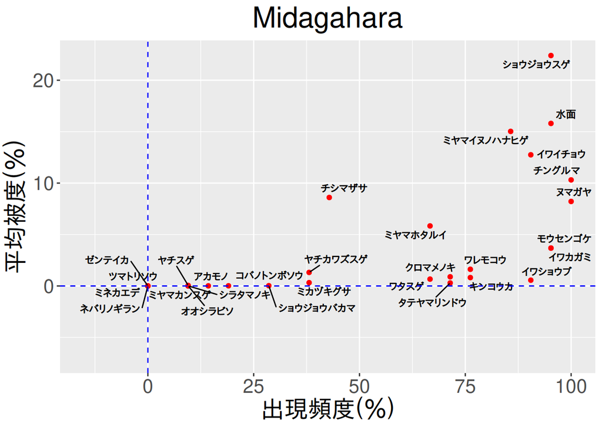

```r
Fig_FrequencyCoverage(plot_name=plot_name,x="f5",y="c5")
```

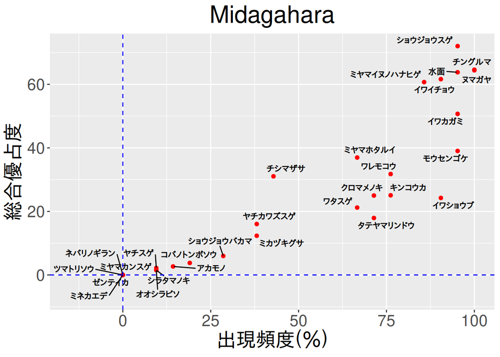

```r
Fig_FrequencyDominace(plot_name=plot_name,x="f5",y="di5")
```

```r
plot_name　<-　"Bunazaka"
DT_VCrepo(plot_name)
```

|  | layer | sp | form | f1 | f2 | f3 | f4 | f5 | F1 | F2 | F3 | F4 | F5 | c1 | c2 | c3 | c4 | c5 | di1 | di2 | di3 | di4 | di5 | cal |
| --- | --- | --- | --- | --- | --- | --- | --- | --- | --- | --- | --- | --- | --- | --- | --- | --- | --- | --- | --- | --- | --- | --- | --- | --- |
| 1 | B2 | アオダモ | bl | 0.5862068965517241 | 0.6206896551724138 | 0.7586206896551724 | 0.7241379310344828 | 0.7931034482758621 | Ⅲ | Ⅳ | Ⅳ | Ⅳ | Ⅳ | 0.3214285714285715 | 0.5 | 0.8571428571428571 | 1.164285714285714 | 1.632142857142857 | 13.72674926266948 | 17.6166065854411 | 24.96302684691113 | 27.85430072655778 | 31.48617649612013 | 1 |
| 2 | B2 | アカミノイヌツゲ | bs | 0 | 0 | 0.1379310344827586 | 0.06896551724137931 | 0.1379310344827586 | - | - | Ⅰ | Ⅰ | Ⅰ | 0 | 0 | 0.05357142857142857 | 0.03571428571428571 | 0.04642857142857143 | 0 | 0 | 2.718301411097812 | 1.569412051435861 | 3.138824102871722 | 0 |
| 3 | B2 | アクシバ | bs | 0.3448275862068966 | 0.4482758620689655 | 0.5172413793103449 | 0.5517241379310345 | 0.5172413793103449 | Ⅱ | Ⅲ | Ⅲ | Ⅲ | Ⅲ | 0.1607142857142857 | 0.2321428571428572 | 0.3214285714285715 | 0.2392857142857143 | 0.5035714285714286 | 7.444375004781977 | 10.2011783343331 | 12.89403573887819 | 13.31690284855426 | 16.08168802256692 | 1 |
| 4 | B2 | ウスノキ | bs | 0 | 0 | 0.06896551724137931 | 0.06896551724137931 | 0.06896551724137931 | - | - | Ⅰ | Ⅰ | Ⅰ | 0 | 0 | 0.03571428571428571 | 0.01785714285714286 | 0.05357142857142857 | 0 | 0 | 1.569412051435861 | 1.109741904046188 | 1.569412051435861 | 0 |
| 5 | B2 | ウリハダカエデ | bl | 0.6896551724137931 | 0.6896551724137931 | 0.7586206896551724 | 0.8275862068965517 | 0.8620689655172413 | Ⅳ | Ⅳ | Ⅳ | Ⅴ | Ⅴ | 0.3392857142857143 | 0.3392857142857143 | 0.4642857142857143 | 0.45 | 0.4257142857142857 | 15.29673650761009 | 15.29673650761009 | 18.76743852443569 | 20.34190510862431 | 21.84529122645136 | 1 |
| 6 | B2 | ウワミズザクラ | bl | 0.3103448275862069 | 0.4482758620689655 | 0.8620689655172413 | 0.8620689655172413 | 0.896551724137931 | Ⅱ | Ⅲ | Ⅴ | Ⅴ | Ⅴ | 0.1607142857142857 | 0.25 | 0.6607142857142857 | 0.6928571428571428 | 1.025 | 7.062354231461376 | 10.58626305724741 | 23.86590205268129 | 25.12285086267043 | 28.85328950520089 | 1 |
| 7 | B2 | エゾユズリハ | bs | 1 | 1 | 1 | 1 | 0.896551724137931 | Ⅴ | Ⅴ | Ⅴ | Ⅴ | Ⅴ | 4.035714285714286 | 6.607142857142857 | 3.053571428571428 | 2.007142857142857 | 1.867857142857143 | 63.52727198388331 | 62.10590034081188 | 48.73397172404481 | 42.25771273642583 | 37.74754094362493 | 1 |
| 8 | B2 | オオカメノキ | bs | 1 | 0.9655172413793104 | 1 | 1 | 1 | Ⅴ | Ⅴ | Ⅴ | Ⅴ | Ⅴ | 3.946428571428572 | 6.625 | 11.46428571428571 | 10.96428571428571 | 11.17857142857143 | 62.82060626441432 | 61.16681543406381 | 66.54751256486924 | 67.08203932499369 | 67.08203932499369 | 1 |
| 9 | B2 | オオバクロモジ | bs | 0.9310344827586207 | 0.896551724137931 | 1 | 1 | 1 | Ⅴ | Ⅴ | Ⅴ | Ⅴ | Ⅴ | 3.714285714285714 | 6.464285714285714 | 7.071428571428571 | 6.642857142857143 | 8.071428571428571 | 58.80585071927566 | 57.14901444659171 | 63.24555320336759 | 62.10590034081188 | 62.67831705280086 | 1 |
| 10 | B2 | クマイチゴ | bs | 0 | 0.06896551724137931 | 0 | 0 | 0 | - | Ⅰ | - | - | - | 0 | 0.01785714285714286 | 0 | 0 | 0 | 0 | 1.109741904046188 | 0 | 0 | 0 | 0 |

[output cut: 79 more lines]

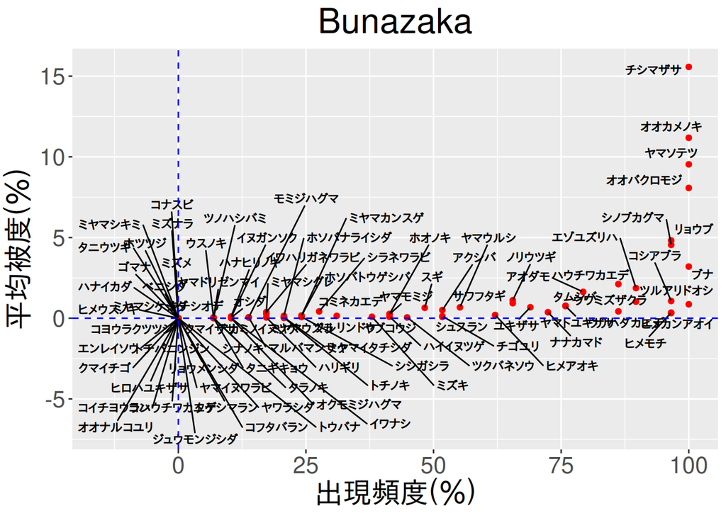

```r
Fig_FrequencyCoverage(plot_name=plot_name,x="f5",y="c5")
```

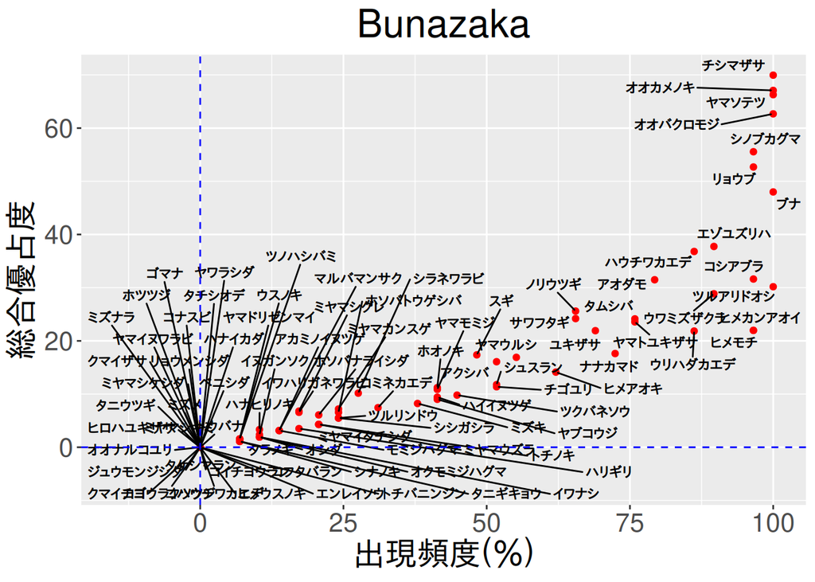

```r
Fig_FrequencyDominace(plot_name=plot_name,x="f5",y="di5")
```

```r
plot_name　<-　"Mimatsu"
DT_VCrepo(plot_name)
```

|  | layer | sp | form | f1 | f2 | f3 | f4 | f5 | F1 | F2 | F3 | F4 | F5 | c1 | c2 | c3 | c4 | c5 | di1 | di2 | di3 | di4 | di5 | cal |
| --- | --- | --- | --- | --- | --- | --- | --- | --- | --- | --- | --- | --- | --- | --- | --- | --- | --- | --- | --- | --- | --- | --- | --- | --- |
| 1 | B2 | アクシバ | bs | 0 | 0 | 0.07692307692307693 | 0 | 0 | - | - | Ⅰ | - | - | 0 | 0 | 0.02 | 0 | 0 | 0 | 0 | 1.240347345892085 | 0 | 0 | 0 |
| 2 | B2 | ウラジロナナカマド | bs | 0 | 0.07692307692307693 | 0.07692307692307693 | 0.07692307692307693 | 0.07692307692307693 | - | Ⅰ | Ⅰ | Ⅰ | Ⅰ | 0 | 0.08 | 0.08 | 0.12 | 0.12 | 0 | 2.480694691784169 | 2.480694691784169 | 3.038218101251 | 3.038218101251 | 0 |
| 3 | B2 | ウラジロヨウラク | bs | 0 | 0 | 0.07692307692307693 | 0 | 0 | - | - | Ⅰ | - | - | 0 | 0 | 0.02 | 0 | 0 | 0 | 0 | 1.240347345892085 | 0 | 0 | 0 |
| 4 | B2 | オオカメノキ | bs | 0.4230769230769231 | 0.4615384615384616 | 0.5384615384615384 | 0.5769230769230769 | 0.5769230769230769 | Ⅲ | Ⅲ | Ⅲ | Ⅲ | Ⅲ | 0.78 | 0.74 | 0.724 | 0.476 | 0.476 | 18.16590212458495 | 17.97434068545834 | 19.13514688090599 | 16.98415551216893 | 16.98415551216893 | 1 |
| 5 | B2 | オオシラビソ | cl | 0.8461538461538461 | 0.7692307692307693 | 0.8846153846153846 | 0.8846153846153846 | 0.8846153846153846 | Ⅴ | Ⅳ | Ⅴ | Ⅴ | Ⅴ | 3.1 | 5.04 | 4.464 | 2.536 | 2.536 | 51.21598308220709 | 45.06405697192864 | 42.06222496766866 | 39.68142367173063 | 39.68142367173063 | 1 |
| 6 | B2 | オオバスノキ | bs | 0.5384615384615384 | 0.7692307692307693 | 0.7692307692307693 | 0.6923076923076923 | 0.6923076923076923 | Ⅲ | Ⅳ | Ⅳ | Ⅳ | Ⅳ | 1.5 | 2.76 | 2.164 | 1.852 | 1.852 | 28.41992800294026 | 41.13766756037212 | 34.19401657060441 | 31.35405752174545 | 31.35405752174545 | 1 |
| 7 | B2 | オガラバナ | bs | 0.5384615384615384 | 0.4615384615384616 | 0.5769230769230769 | 0.5 | 0.5 | Ⅲ | Ⅲ | Ⅲ | Ⅲ | Ⅲ | 1.92 | 3.54 | 2.14 | 1 | 1 | 32.15347809874001 | 26.66025563960764 | 28.62220762329085 | 20.97617696340303 | 20.97617696340303 | 1 |
| 8 | B2 | オノエヤナギ | bl | 0.2307692307692308 | 0.2692307692307692 | 0.1923076923076923 | 0.1923076923076923 | 0.1923076923076923 | Ⅱ | Ⅱ | Ⅰ | Ⅰ | Ⅰ | 0.84 | 1.58 | 0.84 | 0.8 | 0.8 | 13.92286442676771 | 15.56623564988312 | 10 | 10 | 10 | 1 |
| 9 | B2 | クマイチゴ | bs | 0 | 0.1153846153846154 | 0 | 0.07692307692307693 | 0.07692307692307693 | - | Ⅰ | - | Ⅰ | Ⅰ | 0 | 0.04 | 0 | 0.02 | 0.02 | 0 | 2.148344622118298 | 0 | 1.240347345892085 | 1.240347345892085 | 0 |
| 10 | B2 | クロウスゴ | bs | 0.6153846153846154 | 0.4230769230769231 | 0.5769230769230769 | 0.5769230769230769 | 0.5769230769230769 | Ⅳ | Ⅲ | Ⅲ | Ⅲ | Ⅲ | 0.76 | 0.58 | 0.484 | 0.368 | 0.368 | 21.62619494252994 | 15.11494420967336 | 16.98415551216893 | 15.56623564988312 | 15.56623564988312 | 1 |

[output cut: 100 more lines]

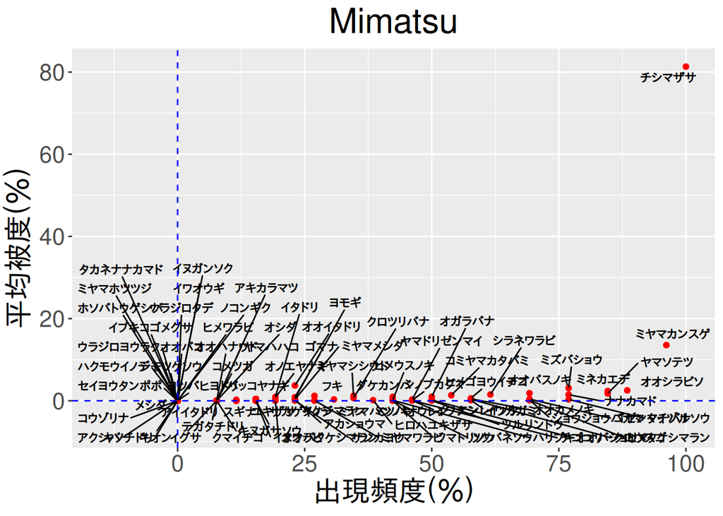

```r
Fig_FrequencyCoverage(plot_name=plot_name,x="f5",y="c5")
```

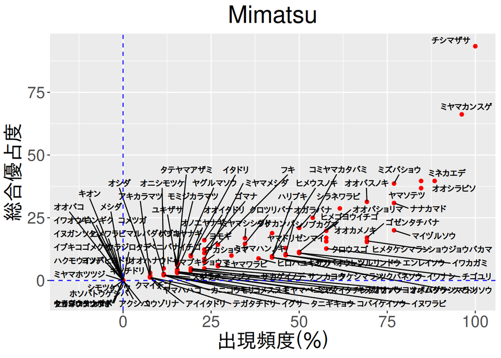

```r
Fig_FrequencyDominace(plot_name=plot_name,x="f5",y="di5")
```

```r
plot_name　<-　"Matsuotoge"
DT_VCrepo(plot_name)
```

|  | layer | sp | form | f1 | f2 | f3 | f4 | f5 | F1 | F2 | F3 | F4 | F5 | c1 | c2 | c3 | c4 | c5 | di1 | di2 | di3 | di4 | di5 | cal |
| --- | --- | --- | --- | --- | --- | --- | --- | --- | --- | --- | --- | --- | --- | --- | --- | --- | --- | --- | --- | --- | --- | --- | --- | --- |
| 1 | B2 | アカミノイヌツゲ | bs | 0.09523809523809523 | 0 | 0.09523809523809523 | 0.09523809523809523 | 0.09523809523809523 | Ⅰ | - | Ⅰ | Ⅰ | Ⅰ | 0.025 | 0 | 0.025 | 0.025 | 0.025 | 1.543033499620919 | 0 | 1.543033499620919 | 1.543033499620919 | 1.543033499620919 | 0 |
| 2 | B2 | ウラジロハナヒリノキ | bs | 0 | 0 | 0.09523809523809523 | 0.09523809523809523 | 0.1428571428571428 | - | - | Ⅰ | Ⅰ | Ⅰ | 0 | 0 | 0.01 | 0.01 | 0.015 | 0 | 0 | 1.543033499620919 | 1.543033499620919 | 2.672612419124243 | 0 |
| 3 | B2 | オオカメノキ | bs | 0.5714285714285714 | 0.4285714285714285 | 0.6190476190476191 | 0.7142857142857143 | 0.6666666666666666 | Ⅲ | Ⅲ | Ⅳ | Ⅳ | Ⅳ | 1.525 | 1.31 | 0.925 | 1.175 | 0.98 | 29.51996902824546 | 21.21320343559642 | 22.93884208478005 | 26.04940361258639 | 25.81988897471611 | 1 |
| 4 | B2 | オオシラビソ | cl | 0.5714285714285714 | 0.2857142857142857 | 0.8571428571428571 | 0.9047619047619048 | 0.9047619047619048 | Ⅲ | Ⅱ | Ⅴ | Ⅴ | Ⅴ | 1.225 | 0.92 | 0.275 | 0.485 | 0.4 | 26.45751311064591 | 11.64964745021435 | 20.17778127403648 | 23.2992949004287 | 23.2992949004287 | 1 |
| 5 | B2 | オオバスノキ | bs | 0.7619047619047619 | 0.3333333333333333 | 0.8095238095238095 | 0.9047619047619048 | 0.8571428571428571 | Ⅳ | Ⅱ | Ⅴ | Ⅴ | Ⅴ | 1.5 | 0.61 | 0.435 | 0.35 | 0.345 | 33.80617018914067 | 13.5400640077266 | 20.11869540407391 | 21.26924898488314 | 20.70196678027062 | 1 |
| 6 | B2 | キタゴヨウ | cl | 0 | 0 | 0 | 0 | 0.09523809523809523 | - | - | - | - | Ⅰ | 0 | 0 | 0 | 0 | 0.005 | 0 | 0 | 0 | 0 | 1.543033499620919 | 0 |
| 7 | B2 | クロウスゴ | bs | 0.4285714285714285 | 0.3809523809523809 | 0.5714285714285714 | 0.4761904761904762 | 0.4761904761904762 | Ⅲ | Ⅱ | Ⅲ | Ⅲ | Ⅲ | 0.65 | 0.715 | 0.58 | 0.575 | 1.405 | 16.6904592079256 | 15.43033499620919 | 18.12653934349931 | 16.18347187425374 | 17.59328876372492 | 1 |
| 8 | B2 | コシアブラ | bl | 0 | 0 | 0.2857142857142857 | 0.3333333333333333 | 0.2857142857142857 | - | - | Ⅱ | Ⅱ | Ⅱ | 0 | 0 | 0.03 | 0.03 | 0.025 | 0 | 0 | 5.976143046671968 | 7.071067811865476 | 5.976143046671968 | 0 |
| 9 | B2 | コヨウラクツツジ | bs | 0.2857142857142857 | 0.1904761904761905 | 0.2857142857142857 | 0.2857142857142857 | 0.2380952380952381 | Ⅱ | Ⅰ | Ⅱ | Ⅱ | Ⅱ | 0.2 | 0.105 | 0.095 | 0.06 | 0.03 | 7.559289460184544 | 4.879500364742666 | 5.976143046671968 | 5.976143046671968 | 4.879500364742666 | 1 |
| 10 | B2 | ダケカンバ | bl | 0.09523809523809523 | 0.09523809523809523 | 0 | 0.09523809523809523 | 0.2380952380952381 | Ⅰ | Ⅰ | - | Ⅰ | Ⅱ | 0.025 | 0.005 | 0 | 0.005 | 0.02 | 1.543033499620919 | 1.543033499620919 | 0 | 1.543033499620919 | 4.879500364742666 | 0 |

[output cut: 60 more lines]

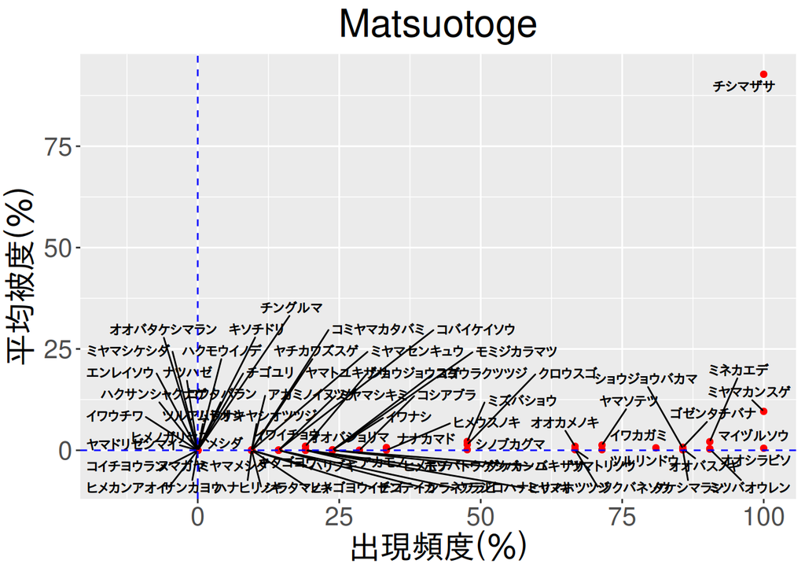

```r
Fig_FrequencyCoverage(plot_name=plot_name,x="f5",y="c5")
```

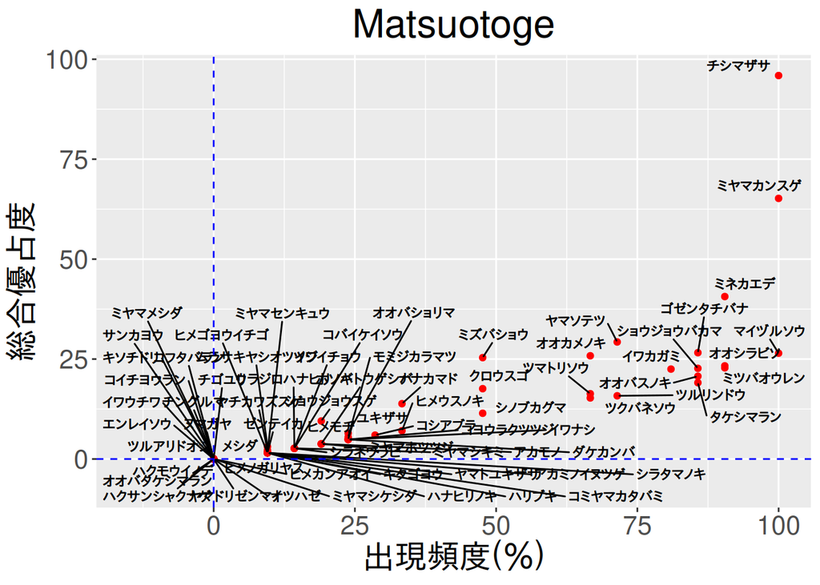

```r
Fig_FrequencyDominace(plot_name=plot_name,x="f5",y="di5")
```

## 9. 浄土山

```r
plot_name　<-　"Joudosan"
DT_VCrepo(plot_name)
```

|  | layer | sp | form | f1 | f2 | f3 | f4 | f5 | F1 | F2 | F3 | F4 | F5 | c1 | c2 | c3 | c4 | c5 | di1 | di2 | di3 | di4 | di5 | cal |
| --- | --- | --- | --- | --- | --- | --- | --- | --- | --- | --- | --- | --- | --- | --- | --- | --- | --- | --- | --- | --- | --- | --- | --- | --- |
| 1 | B2 | ウラジロナナカマド | bs | 0 | 0.07692307692307693 | 0.07692307692307693 | 0.07692307692307693 | 0.07692307692307693 | - | Ⅰ | Ⅰ | Ⅰ | Ⅰ | 0 | 0.04 | 0.08 | 0.04 | 0.04 | 0 | 1.754116038614059 | 2.480694691784169 | 1.754116038614059 | 1.754116038614059 | 0 |
| 2 | B2 | キバナシャクナゲ | bs | 0.8461538461538461 | 0.9230769230769231 | 0.8461538461538461 | 0.8846153846153846 | 0.7307692307692307 | Ⅴ | Ⅴ | Ⅴ | Ⅴ | Ⅳ | 2.82 | 5.22 | 3.12 | 2.224 | 1.096 | 48.84827372747009 | 50.29145821340607 | 40.72421317179177 | 41.63947830900567 | 27.83191306064649 | 1 |
| 3 | B2 | クロウスゴ | bs | 0.1153846153846154 | 0.07692307692307693 | 0.07692307692307693 | 0 | 0.1153846153846154 | Ⅰ | Ⅰ | Ⅰ | - | Ⅰ | 0.1 | 0.04 | 0.08 | 0 | 0.08 | 3.396831102433787 | 1.754116038614059 | 2.480694691784169 | 0 | 3.038218101251 | 0 |
| 4 | B2 | ナナカマド | bs | 0.1923076923076923 | 0.1538461538461539 | 0.1923076923076923 | 0.1538461538461539 | 0.1153846153846154 | Ⅰ | Ⅰ | Ⅰ | Ⅰ | Ⅰ | 0.26 | 0.16 | 0.18 | 0.24 | 0.06 | 7.071067811865476 | 4.961389383568338 | 5.88348405414552 | 6.076436202502 | 2.631174057921087 | 1 |
| 5 | B2 | ハイマツ | cs | 1 | 1 | 1 | 1 | 1 | Ⅴ | Ⅴ | Ⅴ | Ⅴ | Ⅴ | 9.24 | 92.48 | 90.3 | 87.32 | 91.52 | 96.12491872558331 | 95.91663046625438 | 94.65727652959386 | 94.23375191511796 | 94.86832980505137 | 1 |
| 6 | C | アオノツガザクラ | ds | 0 | 0 | 0.1538461538461539 | 0.1538461538461539 | 0.1153846153846154 | - | - | Ⅰ | Ⅰ | Ⅰ | 0 | 0 | 0.18 | 0.14 | 0.32 | 0 | 0 | 5.262348115842174 | 4.640954808922571 | 5.262348115842174 | 0 |
| 7 | C | イワカガミ | h | 0.7692307692307693 | 0.8846153846153846 | 0.9615384615384616 | 0.9615384615384616 | 0.9615384615384616 | Ⅳ | Ⅴ | Ⅴ | Ⅴ | Ⅴ | 2.14 | 4.16 | 1.76 | 2.032 | 1.252 | 40.57282152074028 | 49.41192630872087 | 38.23007273781285 | 40.66750734734246 | 33.96831102433786 | 1 |
| 8 | C | イワスゲ | h | 0.07692307692307693 | 0.07692307692307693 | 0.07692307692307693 | 0.07692307692307693 | 0.07692307692307693 | Ⅰ | Ⅰ | Ⅰ | Ⅰ | Ⅰ | 0.02 | 0.08 | 0.04 | 0.04 | 0.04 | 1.240347345892085 | 2.480694691784169 | 1.754116038614059 | 1.754116038614059 | 1.754116038614059 | 1 |
| 9 | C | ガンコウラン | ds | 0.4230769230769231 | 0.4615384615384616 | 0.5384615384615384 | 0.4230769230769231 | 0.2307692307692308 | Ⅲ | Ⅲ | Ⅲ | Ⅲ | Ⅱ | 1.08 | 1.64 | 0.44 | 0.328 | 0.164 | 21.37575909583276 | 23.92295325221558 | 15.39230577019171 | 11.99358803053339 | 6.445033866354895 | 1 |
| 10 | C | コガネイチゴ | ds | 1 | 1 | 1 | 1 | 0.9615384615384616 | Ⅴ | Ⅴ | Ⅴ | Ⅴ | Ⅴ | 4.48 | 7.92 | 2.48 | 2.38 | 1.858 | 66.93280212272605 | 64.18722614352485 | 48.16637831516917 | 46.26013402488151 | 41.13766756037212 | 1 |

[output cut: 8 more lines]

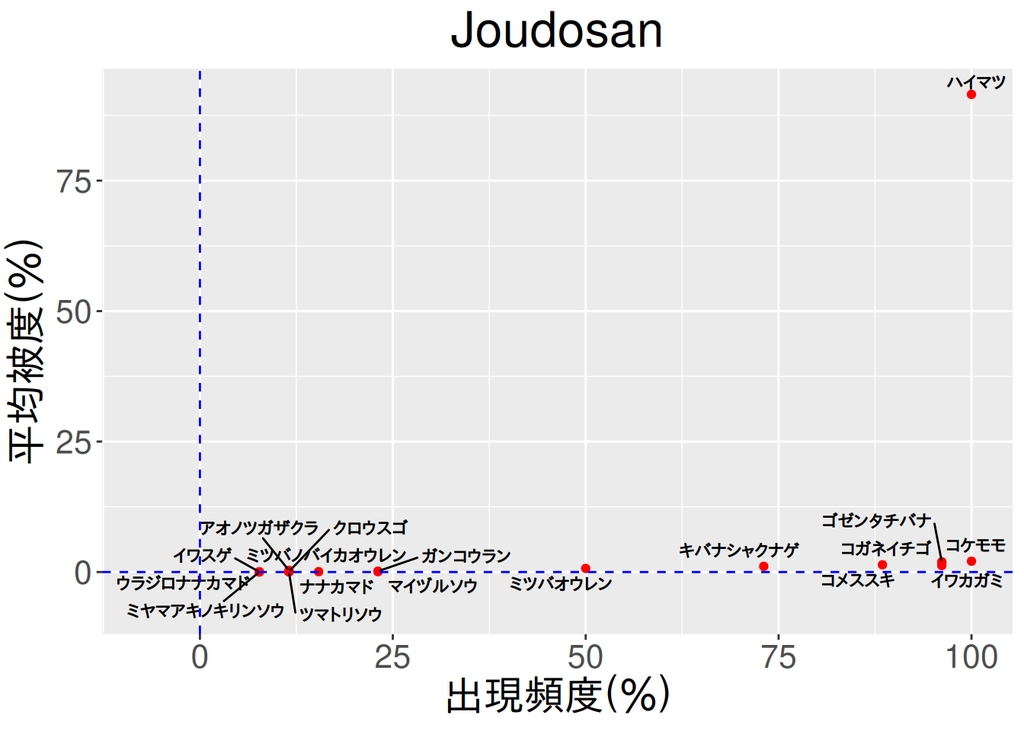

```r
Fig_FrequencyCoverage(plot_name=plot_name,x="f5",y="c5")
```

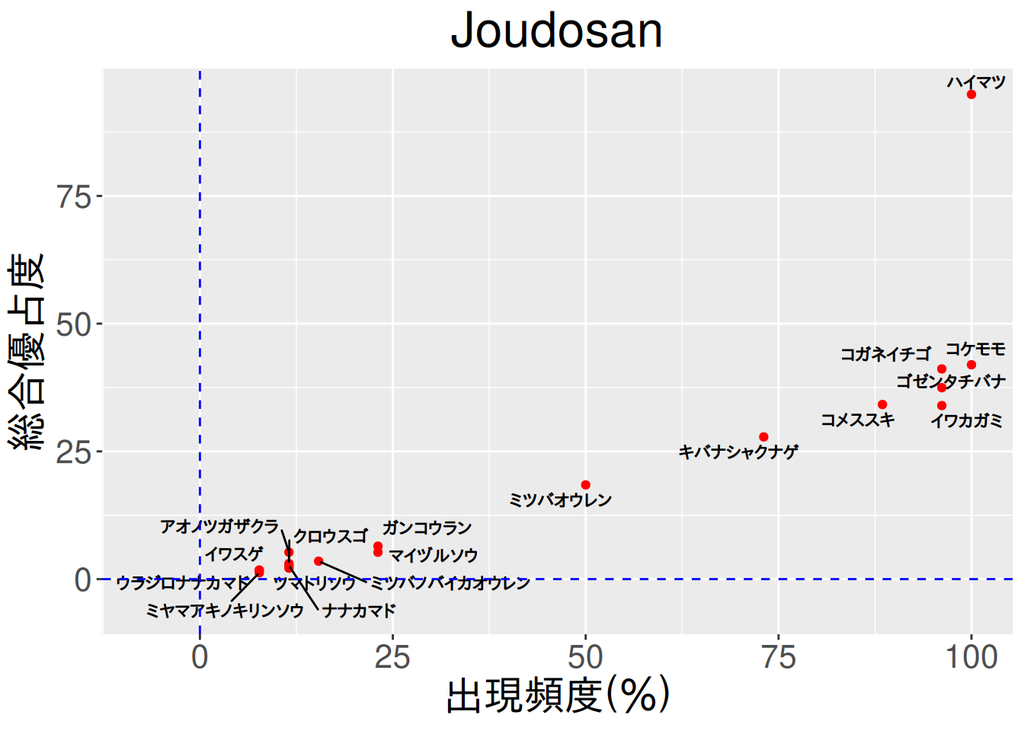

```r
Fig_FrequencyDominace(plot_name=plot_name,x="f5",y="di5")
```

## 10. 有峰

```r
plot_name　<-　"Arimine"
DT_VCrepo(plot_name)
```

|  | layer | sp | form | f1 | f2 | f3 | f4 | f5 | F1 | F2 | F3 | F4 | F5 | c1 | c2 | c3 | c4 | c5 | di1 | di2 | di3 | di4 | di5 | cal |
| --- | --- | --- | --- | --- | --- | --- | --- | --- | --- | --- | --- | --- | --- | --- | --- | --- | --- | --- | --- | --- | --- | --- | --- | --- |
| 1 | B2 | アオダモ | bl | 0.07692307692307693 | 0.6923076923076923 | 0.8846153846153846 | 0.7692307692307693 | 0.7692307692307693 | Ⅰ | Ⅳ | Ⅴ | Ⅳ | Ⅳ | 0.02 | 0.94 | 0.832 | 1 | 1 | 1.240347345892085 | 24.40050440840548 | 27.5820454420848 | 28.2842712474619 | 28.2842712474619 | 1 |
| 2 | B2 | アクシバ | bs | 0 | 0 | 0.07692307692307693 | 0.07692307692307693 | 0.07692307692307693 | - | - | Ⅰ | Ⅰ | Ⅰ | 0 | 0 | 0.04 | 0.08 | 0.08 | 0 | 0 | 1.754116038614059 | 2.480694691784169 | 2.480694691784169 | 0 |
| 3 | B2 | イタヤカエデ | bl | 0.2307692307692308 | 0.4230769230769231 | 0.6923076923076923 | 0.5769230769230769 | 0.5769230769230769 | Ⅱ | Ⅲ | Ⅳ | Ⅲ | Ⅲ | 0.12 | 0.26 | 0.316 | 0.192 | 0.192 | 5.262348115842174 | 10.48808848170151 | 16.64100588675688 | 12.70977818604485 | 12.70977818604485 | 1 |
| 4 | B2 | ウリハダカエデ | bl | 0.4615384615384616 | 0.9230769230769231 | 0.9230769230769231 | 1 | 1 | Ⅲ | Ⅴ | Ⅴ | Ⅴ | Ⅴ | 0.22 | 4 | 2.292 | 2.936 | 2.936 | 10.07662947311558 | 51.56027093083916 | 39.37980739883361 | 45.60701700396552 | 45.60701700396552 | 1 |
| 5 | B2 | ウワミズザクラ | bl | 0.7692307692307693 | 0.6538461538461539 | 0.8076923076923077 | 0.9230769230769231 | 0.9230769230769231 | Ⅳ | Ⅳ | Ⅴ | Ⅴ | Ⅴ | 2.76 | 2.02 | 1.96 | 2.436 | 2.436 | 46.07685886729826 | 32.9451759045936 | 37.70329510186691 | 44.02796314232057 | 44.02796314232057 | 1 |
| 6 | B2 | エゾユズリハ | bs | 0.07692307692307693 | 0.07692307692307693 | 0.1153846153846154 | 0.07692307692307693 | 0.07692307692307693 | Ⅰ | Ⅰ | Ⅰ | Ⅰ | Ⅰ | 0.02 | 0.02 | 0.08 | 0.08 | 0.08 | 1.240347345892085 | 1.240347345892085 | 3.038218101251 | 2.480694691784169 | 2.480694691784169 | 1 |
| 7 | B2 | オオイタヤメイゲツ | bl | 0 | 0 | 0.1538461538461539 | 0 | 0 | - | - | Ⅰ | - | - | 0 | 0 | 0.28 | 0 | 0 | 0 | 0 | 6.076436202502 | 0 | 0 | 0 |
| 8 | B2 | オオカメノキ | bs | 1 | 0.9615384615384616 | 1 | 1 | 1 | Ⅴ | Ⅴ | Ⅴ | Ⅴ | Ⅴ | 5.24 | 13.84 | 15.92 | 16.56 | 16.56 | 72.38784428341543 | 68.21910402406465 | 71.27411872482183 | 72.11102550927978 | 72.11102550927978 | 1 |
| 9 | B2 | オオバクロモジ | bs | 0.9615384615384616 | 0.9615384615384616 | 1 | 1 | 1 | Ⅴ | Ⅴ | Ⅴ | Ⅴ | Ⅴ | 4 | 6.48 | 6.08 | 9.52 | 9.52 | 62.01736729460423 | 60.12806844880863 | 56.5685424949238 | 63.56099432828281 | 63.56099432828281 | 1 |
| 10 | B2 | クサアジサイ | bs | 0.1153846153846154 | 0.1538461538461539 | 0.07692307692307693 | 0 | 0 | Ⅰ | Ⅰ | Ⅰ | - | - | 0.06 | 0.56 | 0.02 | 0 | 0 | 2.631174057921087 | 7.442084075352507 | 1.240347345892085 | 0 | 0 | 0 |

[output cut: 73 more lines]

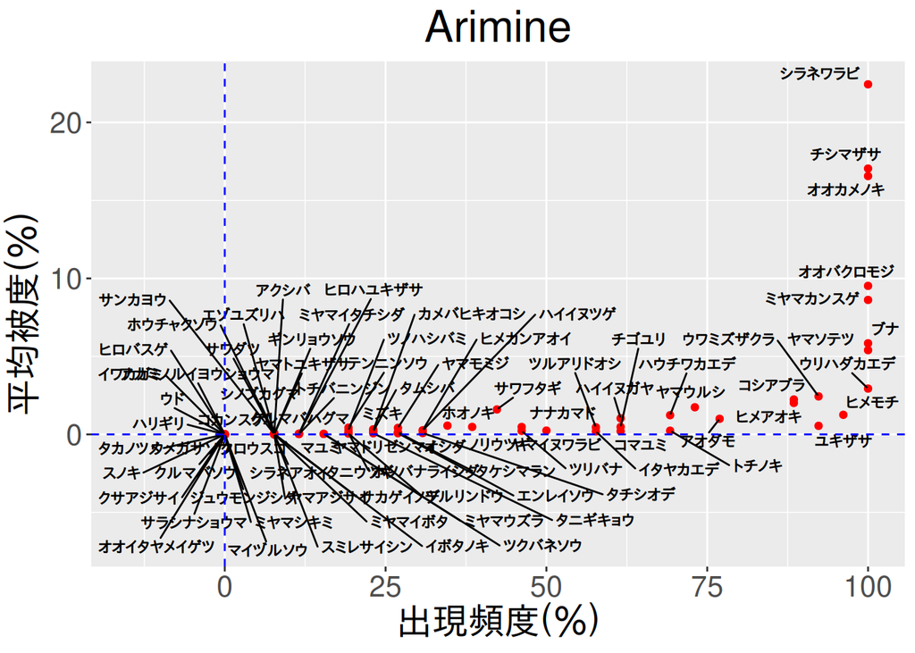

```r
Fig_FrequencyCoverage(plot_name=plot_name,x="f5",y="c5")
```

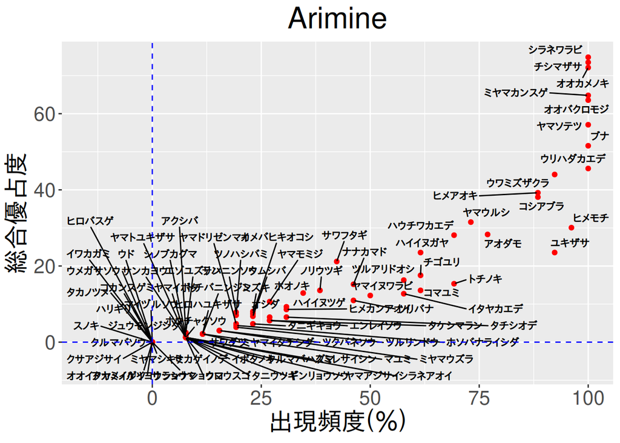

```r
Fig_FrequencyDominace(plot_name=plot_name,x="f5",y="di5")
```

# 全体

## ササの年次変動

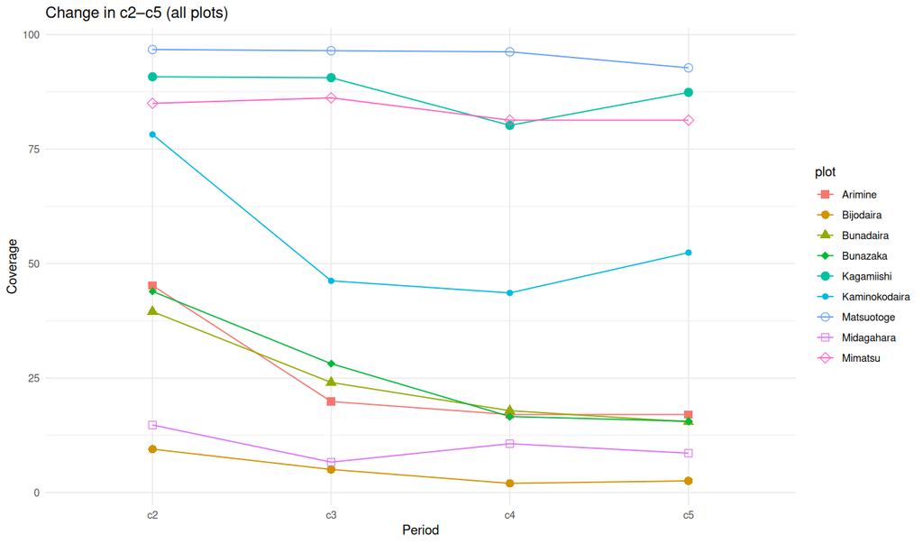

ササの年次変動

# 植物目録

植物目録

FloraList Arimine

```r
DT::datatable(
  flora[, c("spj", "form", "sp")],
  options = list(pageLength = 10),
  caption = "植物目録"
)
```

|  | spj | form | sp |
| --- | --- | --- | --- |
| 1 | アイイタドリ | h | Fallopia x bohemica (Chrtek et Chrtková) J.P.Bailey |
| 2 | アオダモ | bl | Fraxinus lanuginosa Koidz. f. serrata (Nakai) Murata |
| 3 | アオノツガザクラ | ds | Phyllodoce aleutica (Spreng.) A.Heller |
| 4 | アカショウマ | h | Astilbe thunbergii (Siebold et Zucc.) Miq. var. thunbergii |
| 5 | アカミノイヌツゲ | bs | Ilex sugerokii Maxim. var. brevipedunculata (Maxim.) S.Y.Hu |
| 6 | アカミノルイヨウショウマ | h | Actaea erythrocarpa (Turcz. ex Ledeb.) Fisch. ex Freyn |
| 7 | アカモノ | ds | Gaultheria adenothrix (Miq.) Maxim. |
| 8 | アキカラマツ | h | Thalictrum minus L. var. hypoleucum (Siebold et Zucc.) Miq. |
| 9 | アキノキリンソウ | h | Solidago virgaurea L. subsp. asiatica (Nakai ex H.Hara) Kitam. ex H.Hara |
| 10 | アクシバ | bs | Vaccinium japonicum Miq. |

[output cut: 284 more lines]

```r
#flora[, c("spj","form", "sp")]

# knitr::kable(
#   flora[, c("form","spj", "sp")], caption = '植物目録'
# )
```

```r
# DT::datatable(
#   tibble::as_tibble(flora)[, c("spj", "sp", "美女", "ブナ坂", "ブナ平", "上の小",
#                             "弥陀ヶ原", "美松", "松尾峠", "鏡石", "浄土", "有峰")],
#   options = list(
#     pageLength = 10,       # 1ページあたりの行数
#     scrollX = TRUE         # 横スクロールを有効にする
#   )
# )
```

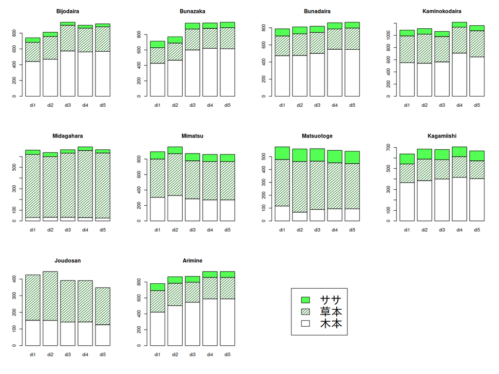

# 謝辞

APG植物目録() 米倉浩司・梶田忠 (2007-) 植物和名ー学名インデックスYList を利用させていただきました。